# D4 Tutorial: Reproducibly Accessing Census Data in Python

**Authors**: June Yang (based on the original work in R by Tyler Fricker & Jessica Godwin)

**Date**: August 30, 2024

This notebook provides a tutorial on reproducibly accessing U.S. Census data using Python.

```python
# Setup
import os
import pandas as pd
import warnings
warnings.filterwarnings("ignore")

# Set Pandas display options
pd.set_option('display.max_columns', None)

# Set the root directory
root_dir = os.path.dirname(os.path.realpath('__file__'))
os.chdir(root_dir)
```

# Introduction

## Why use U.S. Census data in climate research?

U.S. Census data is one of the predominate sources for information on **population size**, particularly when disaggregated by age, sex, race/ethnicity or other demographic and economic variables. Moreover, it is one of the only datasets providing nationally-representative demographic and economic information on **households** and **housing units**. Data is collected every 10 years via the [Decennial Census of Population and Housing](https://www.census.gov/programs-surveys/decennial-census.html), but the [American Community Surve (ACS)](https://www.census.gov/programs-surveys/acs) is an annual survey of households designed to be nationally representative that collects more in-depth information about households and their members than the decennial Census.

It would be impossible to summarize the full array of questions asked in the ACS, but [one particularly relevant question](https://www.census.gov/acs/www/about/why-we-ask-each-question/migration/) is related to household member **migration**:

**Question 15a. Did this person live in this house or apartment 1 year ago? Possible answers:**

- Person is under 1 year old $\rightarrow$ *SKIP to question 16*
- Yes, this house $\rightarrow$ *SKIP to question 16*
- No outside the United States and Puerto Rico - *Print name of foreign country or U.S. Virgin Islands, Guam, etc. below then SKIP to question 16*
- No, different house in the United States or Puerto Rico.

**Question 15b. Where did this person live 1 year ago? Answer fields are: Address, Name of city, town, or post office, Name of U.S. county or municipio in Puerto Rico, Name of U.S. state or Puerto Rico, and ZIP Code.**

Other Census datasets include the [Population Estimates Program](https://www.census.gov/programs-surveys/popest.html) (annual post-censal population and housing units estimates for each state, county, and jurisdiction), the [Current Population Survey](https://www.census.gov/programs-surveys/cps.html) (ongoing surveys on household membership and labor force participation), and many datasets on economic indicators.

### Census geographies and uncertainty

Census data is available at a wide array of spatial resolution, and availability varies by data source. Figure 1 shows the hierarchy of Census geographies. Those geographies that can be built from the basic Census geographic unit, the Census block, like along the vertical **"geographic spine"**. Certain data products are also produced for some of the **"off-spine" geographies** in Figure 1.

[figure not shown]

Decennial Census data is available at all geographies on the spine, but the introduction of **differential privacy** in the 2020 Decennial Census results in published counts that have more uncertainty at the smallest geographies of the spine. 2020 counts for the nation, states and large counties are reported with no uncertainty.

Aggregated, area-level ACS data is available annually at the national, state, and large county or city levels (65,000 or more). Uncertainty in these estimates arise from the **sampling variability** inherent in the household sampling scheme. Though data is collected annually, data is only shared publicly at the Census tract and block group level using 5-years of data. Sub-samples of ACS **microdata**, or person-level data, can be accessed for larger levels of geographies as well.

## Why access Census data with R or Python?

Many Census data tables are available for download as Excel files or .csv's via the Census website and through [this interactive Census website](https://data.census.gov/table). However, accessing this data is not always reproducible. Moreover, you often need to download data for bigger geographic areas than may be of interest to you. Many packages and services exist to incorporate the downloading and accessing of specific variables for specific geographies into a reproducible workflow within R or Python. In addition, these packages often do much of the necessary "heavy-lifting" required to get the data into an easy-to-use format for other data science, GIS, or statistical programming tasks.

This tutorial will provide you with the necessary tools to access the Census data you need in a reproducible way in Python.

## Tutorial Outline

The rest of this tutorial is organized as follows. Section 2 introduces the Census API and Python-based packages for accessing Census data. Section 3 provides an in-depth introduction to using the `census` library to query the Census API. Section 4 provides some tips on how to display or use non-spatial Census data accessed via `census` using `pandas`. Section 5 focuses on Census geographies and map-making using `geopandas`, `us` and `matplotlib`. Finally, Section 6 provides an important overview of how to aggregate Census tract data up to larger geographies that may be of importance to research or policy-makers but are not available in Census data.

# Accessing Census Bureau Data with Python Packages

## The Census API and `census`

The [Census Application Programming Interface (API)](https://www.census.gov/data/developers/guidance/api-user-guide.html) is a tool built by the Census Bureau to allow for the downloading of public use Census data in an easy and systematic way. The Census API can be queried by anyone with the internet and a **Census API Key** (a unique-to-you alphanumeric code issued by the Census Bureau). It is constructed so you can specify the dataset and year you want, the specific variables you want within that dataset, and the geography for which you want the information within a formulaic URL in a relatively intuitive way. (See [examples](https://www.census.gov/data/developers/guidance/api-user-guide.Example_API_Queries.html#list-tab-559651575).) Though you can type these URLs into your internet browser, using functions within R or Python to visit certain URLs that query the API allow for a reproducible workflow. [This online Census Bureau course](https://www.census.gov/data/academy/courses/intro-to-the-census-bureau-data-api.html#1) is useful for those interested in learning more about the Census API

The `census` package ([PyPI](https://pypi.org/project/census/), [GitHub](https://github.com/datamade/census), [Author website](https://github.com/jcarbaugh)) is a Python library written by [Jonathan Carbah](https://github.com/jcarbaugh) and maintained by [Forest Gregg](https://github.com/fgregg) and [Derek Eder](https://github.com/derekeder) that provides a suite of functions that facilitate the construction and implementation of Census API URL queries for more than 1,500 US Census API endpoints, focusing mainly on data from the ACS and the Decennial Census (SF1 and PL datasets).

## IPUMS, NHGIS, and `ipumspy`

[IPUMS](https://www.ipums.org/) provides democratized census and survey data from around the world integrated across time and space. It is the world’s largest accessible database of census microdata, which includes almost a billion records from U.S. censuses from 1790 to the present and over a billion records from the international censuses of over 100 countries.

Beyond census and survey microdata, IPUMS integrates and disseminates area-level census data and electronic boundaries describing census geography for the U.S. and internationally through its [National Historical Geographic Information System (NHGIS)](https://www.nhgis.org/). NHGIS provides easy access to summary tables and time series of population, housing, agriculture, and economic data, along with GIS-compatible mapping files for all census geographies from 1790 through the present.

The `ipumspy` library ([User Guide](https://ipumspy.readthedocs.io/en/latest/#), [GitHub](https://github.com/ipums/ipumspy)) provides a Python interface for handling IPUMS data allowing for users to read files downloaded from the IPUMS extract system, request data, download files, and get metadata from certain IPUMS collectionsm, and process data using the contextual information that is included with many IPUMS files.

## `pandas`, `us`, and `geopandas`

The `pandas` library ([PyPI](https://pypi.org/project/pandas/), [GitHub](https://github.com/pandas-dev/pandas)) is a powerful and flexible Python library for data analysis and manipulation. It provides data structures like Series and DataFrames that allow you to work efficiently with structured data, similar to how `tidycensus` organizes Census data in R. `pandas` is widely used for handling tabular data, enabling operations like filtering, grouping, joining, and aggregating data with ease. Its ability to integrate with other libraries makes it an essential tool for data analysis in Python.

The `us` library ([PyPI](https://pypi.org/project/us/), [GitHub](https://github.com/unitedstates/python-us)) is a lightweight Python package that simplifies working with metadata related to U.S. states and territories. It offers easy access to state names, abbreviations, and FIPS codes, which are crucial when working with U.S. Census data. The library allows for seamless integration with other tools and datasets, making it a valuable resource for geographic data analysis.

The `geopandas` library ([PyPI](https://pypi.org/project/geopandas/), [GitHub](https://github.com/geopandas/geopandas)) extends `pandas` to support geospatial data operations. It allows you to work with geographic data in Python by reading, manipulating, and visualizing spatial datasets such as shapefiles, GeoJSON, and more. `geopandas` provides functionality similar to `tigris` in R by enabling spatial joins, overlays, and other geometric operations, as well as integrating with `matplotlib` for geographic plotting. It is the go-to library for spatial data analysis and mapping in Python.

The `matplotlib` library ([PyPI](https://pypi.org/project/matplotlib/), [GitHub](https://github.com/matplotlib/matplotlib)) is a plotting library for Python that provides a comprehensive set of tools for creating static, animated, and interactive visualizations. It is widely used for creating publication-quality plots, charts, and graphs. `matplotlib` offers customization options, supports multiple backends for rendering, and integrates well with other libraries like `pandas` and `seaborn` for data visualization tasks.

The remainder of this tutorial will focus on using the `census` library to access Census data, and `pandas`, `us`, `matplotlib`, and `geopandas` to work with the data.

It is worth noting that with R, there are dedicated packages such as `tidycensus`, `tigris`, `ggplot2`, and `tmap` that integrate the functionalities of the Python libraries introduced in this tutorial, especially for mapping. For those interested, please refer to the D4 Tutorial on **Reproducibly Accessing Census Data in R**.

## Getting and managing your Census API key

To use the `census` library you need to [request your Census API key](http://api.census.gov/data/key_signup.html). This process is quick! Your own personal API key will be delivered to the email address provided.

One challenge with using these packages in a reproducible and group-based workflow is the management of API keys. Each member of the team who will be using any code that queries the Census APIs needs *their own API key*. API keys are not meant to be shared.

One nice work around is to have everyone in a group create their own Python script such as the file CensusAPIKey.py in Figure 2. This purpose will assign an individual's Census API code to a character object with a common name. In this example, everyone's API character string is assigned to an object called `myKey`.

[figure not shown]

When initializing your group's GitHub repository, add the name of this file to your `.gitignore` file as in Figure 3. **NB: It's best to do this before adding the CensusAPIKey.py to your repository.**

[figure not shown]

Once your `.gitignore` is modified and pushed, every team member can have their own CensusAPIKey.py file on their own machine that is never pushed to GitHub. Your team's code can be written in such a way that if CensusAPIKey.py is sourced in a script, every time an API key is needed a reference to the object `myKey` will be sufficient regardless of which team member is executing code. See example using `census` below.

```python
# import libraries
from census import Census
from us import states

### Load Census API Key ####
# Assuming your CensusAPIKey.py file is in the same directory as your script
from CensusAPIKey import myKey

### Set session API key in Census library ####
c = Census(myKey)
```

# Using `pandas`, `census`, and `us`

The `pandas`, `census`, and `us` libraries in Python together provide powerful functionality for accessing and analyzing U.S. Census data. There are extensive resources available to help users get started with these libraries. The official documentation for each library and various tutorials provide ample guidance for both beginners and advanced users.

## Selecting variables and tables

To access Census data via the census library in Python, you need to know the following information:

```
•	The dataset
•	The specific variable name,
•	The year of data you want,
•	The geographic level for the data (e.g., state, county),
•	The temporal scale for the data (ACS only: single year, 3-year, or 5-year),
•	Your Census API key.
```

In the subsections below, we briefly discuss the selection process and how it relates to querying Census data with the `census` library in Python. Following that, we provide full start-to-finish examples of querying both the Decennial Census and ACS data.

### Datasets

The dataset you choose in the `census` Python library will determine the method used to query the Census API.

To access Decennial Census data, use the `.sf1` method for 2010, which corresponds to Summary File 1 (SF1) data collected every ten years. The `pl` method is used for Redistricting Data Summary File for years 2020, 2010, and 2000. For American Community Survey (ACS) data, you can use the `.acs5` method for 5-year estimates, `acs3` for 3-year estimates, or the `.acs1` method for 1-year estimates. Additionally, the library provides access to specialized ACS Data Profiles and Subject Tables through the `.acs5dp`, `.acs1dp`, and `.acs5st` methods.

### Variable & table names

In the Census API and the `census` library, a variable is uniquely defined by its name, which is typically an alphanumeric code. To retrieve the actual data values, use the `.get()` method combined with the dataset attribute (e.g., `.acs1`, `.acs5`, `.decennial`, `.sf1`) and the variable names. More specific methods, such as the `state_county()` method, are also available to retrieve data for a specific geography.

According to the [PyPI documentation](https://pypi.org/project/census/), the `get()` method is the core data access method on both the ACS and SF1 data sets. The first parameter is either a single string column or a tuple of columns. The second parameter is a geoemtry dict with a `for` key and on option `in` key. The `for` argument accepts a “*” wildcard character or `Census.ALL`. The wildcard is not valid for the `in`parameter.

A variable's name is passed as a character string to the `fields` argument of the `.get()` functions. This is the unique identifier for a variable, usually in the format of a table ID followed by a numeric suffix. For example, "B01001_001E".

```
•    The prefix (e.g., "B01001") identifies the table.
•    The numeric part (e.g., "001") identifies the specific variable within that table.
•    The suffix "E" typically stands for "Estimate" (as opposed to "M" for "Margin of Error").
```

If you would like to select more than one variable in the same API query, you can directly pass the name of the variables to the `fields` argument. For example, `(`NAME`,'B01001_001E', 'B01001_002E')`, where `NAME` is the name of the geography.

The `.tables()` method retrieves metadata about the tables available in a specific Census dataset for a given year. It provides information about the structure and content of the data tables without actually fetching the data itself. Each table dictionary typically includes:

```
•   'name': The table identifier (e.g., 'B01001' for the table of total population by sex and age),
•   'description': A brief description of what the table contains,
•   'variables': A URL to get more detailed information about the variables in this table,
•   'universe ': (Note the space) The population or subset that the table describes
```

```python
tables = c.acs1.tables(year=2021)

# Find the B01001 table
# Note that the table is also searchable by the 'description' field
b01001_info = next((table for table in tables if table['name'] == 'B01001'), None)

if b01001_info:
    print("\nTable Information:")
    print(f"Name: {b01001_info['name']}")
    print(f"Description: {b01001_info['description']}")
    print(f"Universe: {b01001_info['universe ']}") # an extra space at the end of the key 'universe'
    print(f"Variables URL: {b01001_info['variables']}")
else:
    print("Table B01001 not found")
```

```
Table Information:
Name: B01001
Description: SEX BY AGE
Universe: Total population
Variables URL: http://api.census.gov/data/2021/acs/acs1/groups/B01001.json
```

The Variables URL provides a detailed description of each variable in the table, including its name, label, concept, and other attributes.

#### Tips for searching

If you are unsure which variable you need, it is helpful to load and explore the data tables from the dataset as a starting point. In Python, you can achieve this by getting the table metadata, saving it into a DataFrame and then searching through the `variables` url provided in the metadata for the list of variables contained in the table.

There are only a few unique descriptions in the 2020 Decennial Census, so manually searching through them is feasible.

```python
# Load tables for the 2020 Decennial Census
dec_vars_2020 = c.pl.tables(year=2020)

# Convert to DataFrame
df_vars_2020 = pd.DataFrame(dec_vars_2020)

# Get unique descriptions
unique_descriptions_2020 = df_vars_2020['description'].unique()

# Print unique descriptions
print("Unique concepts in 2020 Decennial Census:")
for description in unique_descriptions_2020:
    print(description)
```

```
Unique concepts in 2020 Decennial Census:
RACE
HISPANIC OR LATINO, AND NOT HISPANIC OR LATINO BY RACE
RACE FOR THE POPULATION 18 YEARS AND OVER
HISPANIC OR LATINO, AND NOT HISPANIC OR LATINO BY RACE FOR THE POPULATION 18 YEARS AND OVER
GROUP QUARTERS POPULATION BY MAJOR GROUP QUARTERS TYPE
OCCUPANCY STATUS
```

The 2021 ACS contains many more unique table descriptions (1,200 in total!), so searching by hand is more challenging.

```python
# Load tables for the 2021 ACS 1-Year dataset
acs_tables_2021 = pd.DataFrame(c.acs1.tables(year=2021))

# Get the number of unique descriptions (concepts)
num_unique_concepts_2021 = len(acs_tables_2021['description'].unique())
print(num_unique_concepts_2021)
```

```
1200
```

To get an idea of the types of tables, you can explore the unique descriptions:

```python
# View unique descriptions in the ACS 2021 dataset
unique_descriptions_2021 = acs_tables_2021['description'].unique()
print(unique_descriptions_2021)
```

```
['POVERTY STATUS IN THE PAST 12 MONTHS OF FAMILIES BY FAMILY TYPE BY SOCIAL SECURITY INCOME BY SUPPLEMENTAL SECURITY INCOME (SSI) AND CASH PUBLIC ASSISTANCE INCOME'
 'SEX BY AGE BY COGNITIVE DIFFICULTY'
 'POVERTY STATUS IN THE PAST 12 MONTHS OF FAMILIES BY FAMILY TYPE BY WORK EXPERIENCE OF HOUSEHOLDER AND SPOUSE'
 ...
 'RELATIONSHIP TO HOUSEHOLDER FOR CHILDREN UNDER 18 YEARS IN HOUSEHOLDS'
 'ALLOCATION OF FERTILITY OF WOMEN 15 TO 50 YEARS'
 'RECEIPT OF SUPPLEMENTAL SECURITY INCOME (SSI), CASH PUBLIC ASSISTANCE INCOME, OR FOOD STAMPS/SNAP IN THE PAST 12 MONTHS BY HOUSEHOLD TYPE FOR CHILDREN UNDER 18 YEARS IN HOUSEHOLDS']
```

Once you know some keywords that may be a part of your description of interest, you can use regular expression and string manipulation functions to filter down the descriptions. For example, scrolling through the above output will show you that migration questions almost all contain the phrase "GEOGRAPHICAL MOBILITY".

```python
# Filter down to tables containing "GEOGRAPHICAL MOBILITY" in the description
geo_mobility_descriptions = acs_tables_2021[acs_tables_2021['description'].str.contains("GEOGRAPHICAL MOBILITY", case=False, na=False)]['description']

# Set the maximum column width to a larger value, e.g., 1000 characters
pd.set_option('display.max_colwidth', 1000)
# Display the first few rows of the filtered DataFrame
print(geo_mobility_descriptions.head())
```

```
8                                                             GEOGRAPHICAL MOBILITY IN THE PAST YEAR BY AGE FOR CURRENT RESIDENCE IN PUERTO RICO
36    GEOGRAPHICAL MOBILITY IN THE PAST YEAR FOR CURRENT RESIDENCE--NOT METROPOLITAN OR MICROPOLITAN STATISTICAL AREA LEVEL IN THE UNITED STATES
38                              GEOGRAPHICAL MOBILITY IN THE PAST YEAR FOR CURRENT RESIDENCE--STATE, COUNTY AND PLACE LEVEL IN THE UNITED STATES
39                                              GEOGRAPHICAL MOBILITY IN THE PAST YEAR BY MARITAL STATUS FOR RESIDENCE 1 YEAR AGO IN PUERTO RICO
40                        GEOGRAPHICAL MOBILITY IN THE PAST YEAR FOR CURRENT RESIDENCE--METROPOLITAN STATISTICAL AREA LEVEL IN THE UNITED STATES
Name: description, dtype: object
```

If we know we are interested in breakdowns by age, we might try the following:

```python
# Filter down to variables containing both "GEOGRAPHICAL MOBILITY" and "AGE" in the description
geo_mobility_age_vars = acs_tables_2021[
    acs_tables_2021['description'].str.contains("GEOGRAPHICAL MOBILITY") &
    acs_tables_2021['description'].str.contains("AGE")
]

# Display unique descriptions related to GEOGRAPHICAL MOBILITY and AGE
print(geo_mobility_age_vars['description'].unique())
```

```
['GEOGRAPHICAL MOBILITY IN THE PAST YEAR BY AGE FOR CURRENT RESIDENCE IN PUERTO RICO'
 'MEDIAN AGE BY GEOGRAPHICAL MOBILITY IN THE PAST YEAR FOR CURRENT RESIDENCE IN THE UNITED STATES'
 'GEOGRAPHICAL MOBILITY IN THE PAST YEAR BY AGE FOR CURRENT RESIDENCE IN THE UNITED STATES'
 'MEDIAN AGE BY GEOGRAPHICAL MOBILITY IN THE PAST YEAR FOR RESIDENCE 1 YEAR AGO IN PUERTO RICO'
 'GEOGRAPHICAL MOBILITY IN THE PAST YEAR BY AGE FOR RESIDENCE 1 YEAR AGO IN THE UNITED STATES'
 'MEDIAN AGE BY GEOGRAPHICAL MOBILITY IN THE PAST YEAR FOR RESIDENCE 1 YEAR AGO IN THE UNITED STATES'
 'MEDIAN AGE BY GEOGRAPHICAL MOBILITY IN THE PAST YEAR FOR CURRENT RESIDENCE IN PUERTO RICO'
 'GEOGRAPHICAL MOBILITY IN THE PAST YEAR BY AGE FOR RESIDENCE 1 YEAR AGO IN PUERTO RICO']
```

Now, we have a reasonable number of descriptions to choose from. The next step is to figure out what combination of strings will uniquely identify the description you want. If we are interested in "GEOGRAPHICAL MOBILITY IN THE PAST YEAR BY AGE FOR CURRENT RESIDENCE IN PUERTO RICO" you have two options for identifying the concept and variables you want:

```python
# Filter for an exact string match in the 'description' field
exact_match = acs_tables_2021[acs_tables_2021['description'] == "GEOGRAPHICAL MOBILITY IN THE PAST YEAR BY AGE FOR CURRENT RESIDENCE IN PUERTO RICO"]

# Select and display unique descriptions
print(exact_match['description'].unique())
```

```
['GEOGRAPHICAL MOBILITY IN THE PAST YEAR BY AGE FOR CURRENT RESIDENCE IN PUERTO RICO']
```

```python
# Filter using multiple conditions (AND)
partial_match = acs_tables_2021[
    acs_tables_2021['description'].str.contains("GEOGRAPHICAL MOBILITY") &
    acs_tables_2021['description'].str.contains("BY AGE") &
    acs_tables_2021['description'].str.contains("CURRENT") &
    acs_tables_2021['description'].str.contains("PUERTO")
]

# Select and display unique descriptions (concepts)
print(partial_match['description'].unique())
```

```
['GEOGRAPHICAL MOBILITY IN THE PAST YEAR BY AGE FOR CURRENT RESIDENCE IN PUERTO RICO']
```

You could store the table string to be used in the `.table()` argument to get a list of all the variables in the table metadata `variables`. Details of retrieving the variable values from the metadata are provided in the below sections.

```python
# Store the list of table names
acs_tables_to_pull = acs_tables_2021[
    acs_tables_2021['description'].str.contains("GEOGRAPHICAL MOBILITY") &
    acs_tables_2021['description'].str.contains("BY AGE") &
    acs_tables_2021['description'].str.contains("CURRENT") &
    acs_tables_2021['description'].str.contains("PUERTO")
]['name'].tolist()

print(acs_tables_to_pull)
```

```
['B07001PR', 'C07001PR']
```

In the ACS, the table name is usually the first six characters of the variable name. In this example, the Table name is B07001PR, with "PR" indicating Puerto Rico. If we would like to get into more details, and figure out the difference between the B07001 and C07001 tables, we can refer to the census [API documentation](https://api.census.gov/data/2021/acs/acs1/variables.html) for more details. The C07001 table has a wider age range, compared to the B07001 table.

### Data Year

In the Python `census` library, both the ACS and Decennial Census methods have a year argument. The usage of this argument varies slightly depending on the dataset:

- For Decennial Census data (using `.pl` or `.sf1`), and ACS 1-year data (using `.acs1`), the `year` argument specifies the census year you want data for.
- For ACS 3-year and 5-year data (using `.acs3`, or `.acs5`), the `year` argument can be used to specify the end year of the 3-year or5-year period for which you want data. For example, `year=2021` for ACS 5-year will fetch data for the period 2017-2021.

### Geographic Scale

Both the Decennial Census and ACS methods require you to specify the geographic level at which you want to retrieve data. This can be done through the second argument of the `.get()` method, which is a dictionary specifying the geographic parameters. The geographic scale is specified using the 'for' key in this dictionary. Some common geographic levels include:

- State level: {'for': 'state:*'}
- County level: {'for': 'county:*'}
- Census tract level: {'for': 'tract:*'}
- Place level: {'for': 'place:*'}

You can also specify nested geographies using the 'in' key. For example, to get data for all counties within a specific state:

```python
{'for': 'county:*', 'in': 'state:06'}  # All counties in California (FIPS code 06)
```

```
{'for': 'county:*', 'in': 'state:06'}
```

The exact geographies available may vary depending on the specific dataset (Decennial Census or ACS) and the year of data you're requesting. Always refer to the Census Bureau's documentation for the most up-to-date information on available geographies for each dataset.

### Temporal Scale

Once you've determined your dataset of interest and your geographic scale, you're ready to specify your temporal scale. In the `census` library, this is typically handled through the choice of dataset method and the year argument.

- Decennial Census For the decennial Census, you'll be requesting data at a single year scale regardless of your geography. In the Python `census` library, you use different methods depending on the Census year: For 2020: Use the `c.pl` method (PL 94-171 Redistricting Data), For 2010 and earlier: Use the `c.sf1` method (Summary File 1)

```python
# Example for 2020 Decennial Census
data = c.pl.get(('NAME', 'P1_001N'), {'for': 'state:*'}, year=2020)

# Example for 2010 Decennial Census
data = c.sf1.get(('NAME', 'P001001'), {'for': 'state:*'}, year=2010)
```

- American Community Survey (ACS) For the ACS, you'll be requesting data at either the 1-year, 3-year or 5-year scale, depending on your choice of geography. The `census`library provides different methods for these:

  For 1-year ACS: Use the `c.acs1` method

  For 5-year ACS: Use the `c.acs5` method

For national, state, and large counties or cities (Census places), you can usually use the 1-year ACS:

```python
data = c.acs1.get(('NAME', 'B01001_001E'), {'for': 'state:*'}, year=2021)
```

For small counties or places, tracts, or block groups, you'll almost certainly need to use the 5-year ACS:

```python
data = c.acs5.get(('NAME', 'B01001_001E'), {'for': 'tract:*', 'in': 'state:06'}, year=2021)
```

## Querying the Census API

### Using `.get()` for Decennial Census

Below we provide code for pulling counts of total housing units for each county in the state of Washington from the 2020 decennial Census using the following information:

- Dataset: Decennial Census: `.pl`
- Dataset-specific variables: Total housing units: `H1_001N`
- The annual timeframe: 2020
- Geographic Level: all counties in the state of 'WA'
- Temporal Scale: Single year of 2020
- Your Census API key

```python
# Load all libraries if not already loaded
# from census import Census
# import pandas as pd

from us import states
# Assuming you've already set up your Census object with your API key
c = Census(myKey)

# Get 2020 Decennial Census data
hu_wa_2020 = c.pl.get(
    ("NAME", "H1_001N"),
    {'for': 'county:*', 'in': f'state:{states.WA.fips}'},
    year=2020
)

# Convert to DataFrame for easier viewing
hu_wa_2020_df = pd.DataFrame(hu_wa_2020)
print(hu_wa_2020_df.head())
```

```
                         NAME  H1_001N state county
0    Adams County, Washington   6735.0    53    001
1   Asotin County, Washington  10034.0    53    003
2   Benton County, Washington  80076.0    53    005
3   Chelan County, Washington  37267.0    53    007
4  Clallam County, Washington  37930.0    53    009
```

#### A note on ID of geographies of the output

The output of the `.get()` function does not include a concatenated column on `GEOID`, instead, it includes the standard Census numeric code for a particular geography at each level. States and counties are determined by their [Federal Information Processing Series(FIPS) codes](https://www.census.gov/library/reference/code-lists/ansi.html).

In the example above, we use the `us` library to get the FIPS code for Washington state. The output of the `c.pl.get()` function that we specified includes a `state` and `county` ID for each county in Washington state. The structure of the IDs is as follows:

The **state** code is 2 digits long, Washington's FIPS code is 53.

The **county** code within each state is 3 digits long. Adams County's unique code within Washington is 001, so we see 001 in the `county` column for Adams County.

The **tract** code that uniquely identifies a Census tract within a county is 6 digits long. The resulting ID for a tract in Adams County, Washington is then 53001TTTTTT, where TTTTTT represents a 6-digit tract code.

The **block group** code that uniquely identifies each Census block group within a certain Census tract, TTTTTT, within Adams County, Washington is 1 digit long. The resulting ID for a block group within tract TTTTTT in Adams County, Washington is 53001TTTTTTG, where G represents a 1 digit tract code.

The **block** code that uniquely identifies each Census block within a block group, G, within a certain Census tract, TTTTTT, within Adams County, Washington is 3 digits long. The resulting ID for a block group within tract TTTTTT and block group G in Adams County, Washington is 53001TTTTTTGBBB, where BBB represents a 3 digit tract code.

### Using `.get()`for ACS Data

Below we provide code for pulling estimated counts of individuals by sex for King County, Washington from the 2021 ACS using the following information:

Note: Different from `tidycensus` in R, In the Python `census` library, we need to explicitly request both the estimate ('E' suffix) and margin of error ('M' suffix) for each variable.

The output of the `.get()` method normally contains the name of the variable, in addition to the attribute we specified (e.g. `NAME`), and ID columns of the geography we specified. For the ease of presentation, we reshape the output into estimates and margin of error (moe) columns.

```python
# Get 2021 ACS 1-year data for King County, WA
pop_sex_king_2021 = c.acs1.get(
    ("NAME", "B01001_002E", "B01001_002M", "B01001_026E", "B01001_026M"),
    {'for': 'county:033', 'in': f'state:{states.WA.fips}'},
    year=2021
)

# Convert to DataFrame
pop_sex_king_2021_df = pd.DataFrame(pop_sex_king_2021)

# Rename columns for clarity
pop_sex_king_2021_df.columns = ['NAME', 'Male_Estimate', 'Male_MOE', 'Female_Estimate', 'Female_MOE', 'state', 'county']

# Reshape to long format
pop_sex_king_2021_long = pd.melt(
    pop_sex_king_2021_df,
    id_vars=['NAME', 'state', 'county'],
    value_vars=['Male_Estimate', 'Female_Estimate', 'Male_MOE', 'Female_MOE'],
    var_name='temp_var',
    value_name='value'
)

# Separate the temporary variable into 'variable' and 'measure'
pop_sex_king_2021_long[['Sex', 'measure']] = pop_sex_king_2021_long['temp_var'].str.split('_', expand=True)

# Pivot to create separate columns for Estimate and MOE
pop_sex_king_2021_long = pop_sex_king_2021_long.pivot(
    index=['NAME', 'state', 'county', 'Sex'],
    columns='measure',
    values='value'
).reset_index()

# Rename columns and add variable column
pop_sex_king_2021_long = pop_sex_king_2021_long.rename(columns={'Estimate': 'estimate', 'MOE': 'moe'})
pop_sex_king_2021_long['variable'] = pop_sex_king_2021_long['Sex'].map({'Male': 'B01001_002', 'Female': 'B01001_026'})

# Reorder columns
pop_sex_king_2021_long = pop_sex_king_2021_long[['NAME', 'variable', 'estimate', 'moe', 'state', 'county']]

print(pop_sex_king_2021_long)
```

```
measure                     NAME    variable   estimate    moe state county
0        King County, Washington  B01001_026  1111503.0  552.0    53    033
1        King County, Washington  B01001_002  1140802.0  552.0    53    033
```

**NB: The `moe` represents the whole margin of error for a 90% (by default) confidence interval (CI). In other words, estimate + moe will give you the upper limit of a 90% CI and estimate - moe will give you the lower limit.**

To calculate the standard error for each estimate when the default 90% margin of error is used, use the following code:

```python
from scipy import stats
# Calculate standard error
def calculate_se(moe):
     return moe / stats.norm.ppf(0.95)

pop_sex_king_2021_long['se'] = calculate_se(pop_sex_king_2021_long['moe'].astype(float))

# Reorder columns
pop_sex_king_2021_final = pop_sex_king_2021_long[['NAME', 'variable', 'estimate', 'moe', 'se', 'state', 'county']]

print(pop_sex_king_2021_final)
```

```
measure                     NAME    variable   estimate    moe          se  \
0        King County, Washington  B01001_026  1111503.0  552.0  335.592171
1        King County, Washington  B01001_002  1140802.0  552.0  335.592171

measure state county
0          53    033
1          53    033
```

Below we provide code for pulling counts of individuals by sex **and age** for King County, Washington from the 2021 ACS using the following information:

- the dataset: ACS,
- the dataset-specific variable name: all variables in the description "SEX BY AGE" table `B01001`,
- the annual timeframe: `year = 2021`,
- the geographic level county in the state of `WA` and county of `King`,
- the temporal scale: using ACS data at county level, let's use 1-year data `"acs1"`,
- your Census API key

**NB: If we wanted info for a county with a population less than 65,000 we would need to get 5-year data for 2017-2021 using `acs5`.**

The `census` library does not have a built-in function to fetch all variables in a table. Instead, you can use the `tables` method to get the table metadata and then use the `variables` URL to get the variable list. We then use the `requests` library to fetch the variable list from the API.

```python
# load additional libraries
import requests # for accessing the API

# Get the table metadata
tables = c.acs1.tables(year=2021)
b01001_info = next((table for table in tables if table['name'] == 'B01001'), None)

if b01001_info is None:
    print("Table B01001 not found")
    exit()

# Fetch the variable list from the API
url = b01001_info['variables']
response = requests.get(url)
variables = response.json()['variables']

# Get all variable names starting with 'B01001' and ending in 'E' or 'M'
var_names = [var for var in variables if var.startswith('B01001') and (var.endswith('E') or var.endswith('M'))]

# take a look at the variables
print(var_names[:10])
```

```
['B01001_012E', 'B01001_012M', 'B01001_011E', 'B01001_011M', 'B01001_014E', 'B01001_014M', 'B01001_013E', 'B01001_013M', 'B01001_016E', 'B01001_016M']
```

### Directly fetching census data with specific geographic levels

Different from `.get()` method, the `.state_county()` method is a convenience method specifically for fetching county-level data within a state. It's designed to make it easier to get data for counties without having to specify the full geographic hierarchy. It automatically sets up the correct geographic parameters for you. Similarly, the `.state_county_tract()` method is designed to fetch tract-level data within a county.

Based on the variable names in the step listed above, we then fetch the data for King County, WA, and convert it to a DataFrame.

We can reshape the data to wide format to see the estimate and margin of error for each variable.

```python
# Fetch data for King County, WA
pop_sex_age_king_2021 = c.acs1.state_county(
    var_names,
    states.WA.fips,
    '033',
    year=2021
)

# Convert to DataFrame
pop_sex_age_king_2021_df = pd.DataFrame(pop_sex_age_king_2021)

## Identify the data columns (starting with 'B01001' and ending in 'E' or 'M')
data_cols = [col for col in pop_sex_age_king_2021_df.columns if col.startswith('B01001') and (col.endswith('E') or col.endswith('M'))]

# Identify the non-data columns
id_vars = [col for col in pop_sex_age_king_2021_df.columns if col not in data_cols]

# Reshape the data
pop_sex_age_king_2021_long = pop_sex_age_king_2021_df.melt(id_vars=id_vars, value_vars=data_cols, var_name='variable', value_name='value')
pop_sex_age_king_2021_long['type'] = pop_sex_age_king_2021_long['variable'].apply(lambda x: 'estimate' if x.endswith('E') else 'moe')
pop_sex_age_king_2021_long['variable'] = pop_sex_age_king_2021_long['variable'].str[:-1]  # Remove 'E' or 'M' suffix

# Pivot to create separate columns for estimates and MOEs
pop_sex_age_king_2021_wide = pop_sex_age_king_2021_long.pivot(index=id_vars + ['variable'], columns='type', values='value').reset_index()
# Sort by variable name
pop_sex_age_king_2021_final = pop_sex_age_king_2021_wide.sort_values('variable')

# Display the first few rows of the DataFrame
print(pop_sex_age_king_2021_final.head(10))
```

```
type          GEO_ID state county    variable   estimate          moe
0     0500000US53033    53    033  B01001_001  2252305.0 -555555555.0
1     0500000US53033    53    033  B01001_002  1140802.0        552.0
2     0500000US53033    53    033  B01001_003    61208.0        521.0
3     0500000US53033    53    033  B01001_004    62450.0       3251.0
4     0500000US53033    53    033  B01001_005    66507.0       3251.0
5     0500000US53033    53    033  B01001_006    37342.0        367.0
6     0500000US53033    53    033  B01001_007    24238.0        545.0
7     0500000US53033    53    033  B01001_008     9803.0       1545.0
8     0500000US53033    53    033  B01001_009    12053.0       1973.0
9     0500000US53033    53    033  B01001_010    42861.0       2047.0
```

## Dealing with variable labels

Now that we've walked through querying the Census API for the decennial Census and the ACS via the `census` library, we need to cover some basics to make this data more usable. First and foremost, no one will ever be able to remember what every alphanumeric Census variable name is by heart. But, if we use the output of the variables metadata coupled with scraping, and some data-wrangling, we can get neat string labels in no time! The below example is for the B01001 (SEX BY AGE) table.

**Step 1: Get the variables metadata from the API**

Recall that in the metadata output provided by the `.tables()` method, there is a `variables` key that contains an url that points to a dictionary of all the variables in the table. We will get the list of variables in the table by scraping the dictionary.

```python
# Load variables for the 2021 ACS 1-Year dataset
def get_variables_metadata(year, dataset):
    tables = c.acs1.tables(year=year)
    variables_list = []
    for table in tables:
        if table['name'].startswith('B01001'):  # We're interested in the SEX BY AGE table
            url = table['variables']
            response = requests.get(url)
            variables = response.json()['variables']
            for var_name, var_info in variables.items():
                if var_name not in ['for', 'in']:
                    variables_list.append({
                        'name': var_name,
                        'label': var_info.get('label', ''),
                        'concept': var_info.get('concept', '')
                    })
    return pd.DataFrame(variables_list)

acs_var_info_2021 = get_variables_metadata(2021, 'acs1')
print(acs_var_info_2021.head())
```

```
            name                                                        label  \
0  B01001F_002EA                        Annotation of Estimate!!Total:!!Male:
1  B01001F_001EA                               Annotation of Estimate!!Total:
2  B01001F_001MA                        Annotation of Margin of Error!!Total:
3  B01001F_004EA          Annotation of Estimate!!Total:!!Male:!!5 to 9 years
4  B01001F_003MA  Annotation of Margin of Error!!Total:!!Male:!!Under 5 years

                              concept
0  SEX BY AGE (SOME OTHER RACE ALONE)
1  SEX BY AGE (SOME OTHER RACE ALONE)
2  SEX BY AGE (SOME OTHER RACE ALONE)
3  SEX BY AGE (SOME OTHER RACE ALONE)
4  SEX BY AGE (SOME OTHER RACE ALONE)
```

The variable names need to be cleaned up to match the format of the variable names in the `pop_sex_age_king_2021_final` dataframe that we came up with in the previous section. We will keep only the estimates and remove the "E" suffix.

```python
# Clean up variable names
acs_vars_info_subset = acs_var_info_2021[['name', 'label']].copy()
acs_vars_info_subset = acs_vars_info_subset[acs_vars_info_subset['name'].str.endswith('E')]
acs_vars_info_subset['name'] = acs_vars_info_subset['name'].str[:-1]
```

**Step 2: Join metadata with the .get() output**

Below, we join `acs_var_info_2021_subset` onto `pop_sex_age_king_2021_final` by the respective variable name column in each dataset. This still leaves the pesky issue of the "!!" and ":" in the label strings.

```python
# Perform the left join
pop_sex_age_king_2021_labeled = pop_sex_age_king_2021_final.merge(
    acs_vars_info_subset,
    left_on='variable',
    right_on='name',
    how='left'
)

# Remove the 'name' column as it's no longer needed
pop_sex_age_king_2021_labeled = pop_sex_age_king_2021_labeled.drop(columns=['name'])
# Display the first few rows of the labeled DataFrame
print(pop_sex_age_king_2021_labeled.head())
```

```
           GEO_ID state county    variable   estimate          moe  \
0  0500000US53033    53    033  B01001_001  2252305.0 -555555555.0
1  0500000US53033    53    033  B01001_002  1140802.0        552.0
2  0500000US53033    53    033  B01001_003    61208.0        521.0
3  0500000US53033    53    033  B01001_004    62450.0       3251.0
4  0500000US53033    53    033  B01001_005    66507.0       3251.0

                                     label
0                         Estimate!!Total:
1                  Estimate!!Total:!!Male:
2   Estimate!!Total:!!Male:!!Under 5 years
3    Estimate!!Total:!!Male:!!5 to 9 years
4  Estimate!!Total:!!Male:!!10 to 14 years
```

**Step 3: Clean up the variable labels**

How you want to do this will vary for each description, this specific example is appropriate for the "SEX BY AGE" description. The result of this code is extra `sex` and `age` columns added to the ACS data making it easier to plot and analyze.

```python
# Clean up labels by replacing "Estimate!!Total:" and "!!" with an empty string
pop_sex_age_king_2021_labeled['label'] = pop_sex_age_king_2021_labeled['label'].str.replace("Estimate!!Total:", "", regex=False)
pop_sex_age_king_2021_labeled['label'] = pop_sex_age_king_2021_labeled['label'].str.replace("!!", "", regex=False)

# Split label into sex and age
def split_label(label):
    if isinstance(label, str):
        parts = label.split(':')
        sex = parts[0] if parts[0] in ['Male', 'Female'] else 'Total'
        age = parts[1] if len(parts) > 1 else 'Total'
        return pd.Series([sex, age])
    else:
        return pd.Series(['Total', 'Total'])

# Apply the split_label function to each row
pop_sex_age_king_2021_labeled[['sex', 'age']] = pop_sex_age_king_2021_labeled['label'].apply(split_label)
# Check our work
print(pop_sex_age_king_2021_labeled[['variable', 'label', 'sex', 'age']].head(10))
```

```
     variable                 label    sex              age
0  B01001_001                        Total            Total
1  B01001_002                 Male:   Male
2  B01001_003    Male:Under 5 years   Male    Under 5 years
3  B01001_004     Male:5 to 9 years   Male     5 to 9 years
4  B01001_005   Male:10 to 14 years   Male   10 to 14 years
5  B01001_006   Male:15 to 17 years   Male   15 to 17 years
6  B01001_007  Male:18 and 19 years   Male  18 and 19 years
7  B01001_008         Male:20 years   Male         20 years
8  B01001_009         Male:21 years   Male         21 years
9  B01001_010   Male:22 to 24 years   Male   22 to 24 years
```

# Getting results

Suppose you simply want to report the total male and female population in King County in 2021. Our output `pop_sex_king_2021_final` contains all the information you need to make a nice table.

First, like in the last section, we want to work with the labels to get a column named "Sex" containing the words "Male" and "Female".

```python
# Merge and clean up labels
pop_sex_king_2021_labeled = pop_sex_king_2021_final.merge(
    acs_vars_info_subset[['name', 'label']],
    left_on='variable',
    right_on='name',
    how='left'
)

# Clean up labels and create Sex column
pop_sex_king_2021_labeled['label'] = pop_sex_king_2021_labeled['label'].str.replace("Estimate!!Total:", "", regex=False)
pop_sex_king_2021_labeled['label'] = pop_sex_king_2021_labeled['label'].str.replace("!!", "", regex=False)
pop_sex_king_2021_labeled['sex'] = pop_sex_king_2021_labeled['label'].str.replace(":", "", regex=False)

# Drop the `name` and `label` columns
pop_sex_king_2021_labeled = pop_sex_king_2021_labeled.drop(columns=['name', 'label'])
```

```python
pop_sex_king_2021_labeled.head()
```

|  | NAME | variable | estimate | moe | se | state | county | sex |
| --- | --- | --- | --- | --- | --- | --- | --- | --- |
| 0 | King County, Washington | B01001_026 | 1111503.0 | 552.0 | 335.592171 | 53 | 033 | Female |
| 1 | King County, Washington | B01001_002 | 1140802.0 | 552.0 | 335.592171 | 53 | 033 | Male |

Then we can can make a nice table with 90% confidence intervals.

```python
# Create table with confidence intervals
table_data = pop_sex_king_2021_labeled[['sex', 'estimate', 'moe']].copy()
table_data['ci_upper'] = table_data['estimate'] + table_data['moe']
table_data['ci_lower'] = table_data['estimate'] - table_data['moe']
table_data['CI'] = table_data.apply(lambda row: f"({int(row['ci_lower'])}, {int(row['ci_upper'])})", axis=1)

# Select final columns for display
final_table = table_data[['sex', 'estimate', 'CI']]

# Rename columns
final_table.columns = ['Sex', 'Estimate', '90% CI']

# If you want to save this as a nice-looking table, you can use libraries like prettytable or tabulate
# Here's an example using tabulate:

from tabulate import tabulate

print(tabulate(final_table, headers='keys', tablefmt='pipe', showindex=False))
```

```
| Sex    |   Estimate | 90% CI             |
|:-------|-----------:|:-------------------|
| Female | 1.1115e+06 | (1110951, 1112055) |
| Male   | 1.1408e+06 | (1140250, 1141354) |
```

## Multi-year results

One frustrating thing about the `census` library methods is that they **do not** allow you to specify more than one year per API query. Below we provide a simple example of how one might pull data for several years without writing a bunch of unnecessary code or doing a lot of copy & pasting that might result in mistakes.

Suppose we want to pull the total population for King County from 2019-2022.

Previously we saw this can be pulled for 2020 from the decennial Census using variable name "P1_001N", and for the 2021 ACS using the variable "B01001_001". **NB: While few ACS variable names have changed in recent years, it's worth checking the output of `.get()` and/or `.state_county()` for multiple years just in case. In particular, for years prior to 2010.**

We will pull data using a for loop that uses the variable `yr` to loop over year values of 2019, 2020, 2021, and 2022.

Using the `state_county()` method, both the Decennial Census and the ACS results will have the same format with columns named `state`, `county`, and the variable name. We will need to modify the variable names into `estimate` to make it compatible. Finally, we will append a `year` column to each output before combining them into a single dataset.

```python
# Variable name strings
dec_var_to_pull = "P1_001N"
acs_var_to_pull = "B01001_001E"

# Years to loop over
years = [2019, 2020, 2021, 2022]

# Empty list to store results
pop_list = []

for yr in years:
    if yr == 2020:
        # Fetch decennial data for 2020
        data = c.pl.state_county(
            (dec_var_to_pull,),
            states.WA.fips,
            '033',  # King County FIPS
            year=yr
        )
        # Convert to DataFrame and add necessary columns
        df = pd.DataFrame(data)
        df = df.rename(columns={"P1_001N": "estimate"})
        df["year"] = yr
    else:
        # Fetch ACS data for other years
        data = c.acs1.state_county(
            (acs_var_to_pull,),
            states.WA.fips,
            '033',  # King County FIPS
            year=yr
        )
        # Convert to DataFrame and add necessary columns
        df = pd.DataFrame(data)
        df = df.rename(columns={"B01001_001E": "estimate"})
        df["year"] = yr

    # Append the DataFrame to the list
    pop_list.append(df)
```

```python
pop_list
```

```
[    estimate state county  year
 0  2252782.0    53    033  2019,
     estimate state county  year
 0  2269675.0    53    033  2020,
     estimate state county  year
 0  2252305.0    53    033  2021,
     estimate state county  year
 0  2266789.0    53    033  2022]
```

Now we can use this data to make a plot of King County's population over time.

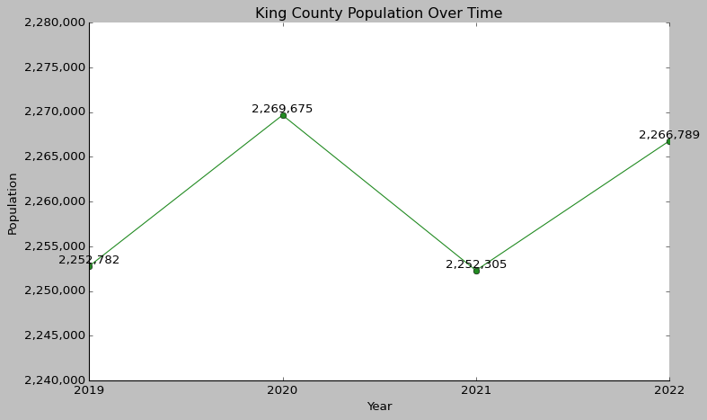

```python
# Import matplotlib for plotting
import matplotlib.pyplot as plt

# Combine the list of DataFrames into a single DataFrame
pop_df = pd.concat(pop_list, ignore_index=True)

# Sort the DataFrame by year to ensure correct order
pop_df = pop_df.sort_values('year')

# Create the plot
plt.figure(figsize=(10, 6))
plt.plot(pop_df['year'].values, pop_df['estimate'].values,
         color='forestgreen', marker='o', linestyle='-')

# Customize the plot
plt.xlabel('Year')
plt.ylabel('Population')
plt.title("King County Population Over Time")

# Use a classic theme
plt.style.use('classic')

# Remove top and right spines
plt.gca().spines['top'].set_visible(False)
plt.gca().spines['right'].set_visible(False)

# Format y-axis labels to use commas as thousand separators
def format_with_commas(x, pos):
    return f'{x:,.0f}'

plt.gca().yaxis.set_major_formatter(plt.FuncFormatter(format_with_commas))

# Set x-axis ticks and labels to show all years correctly
plt.xticks(pop_df['year'], pop_df['year'].astype(int))

# Add data labels
for x, y in zip(pop_df['year'], pop_df['estimate']):
    plt.text(x, y, f'{y:,.0f}', ha='center', va='bottom')

# Adjust y-axis to make room for labels
plt.ylim(2240000, 2280000)

# Show the plot
plt.tight_layout()
plt.show()
```

## Aggregating estimates across tables

Let us return now to our example of sex- and age-specific population. The "B01001" table from the ACS contains population estimates for each sex and age group 0-5, 5-9, 10-14, 15-17, 18-19, 20, 21, 22-24, 25-29, 30-34, 35-39, 40-44, 45-49, 50-54, 55-59, 60-61, 62-64, 65-66, 67-69, 70-74, 75-79, 80-84, and 85+. However, suppose what we want, is actualy 5-year age groups all the way up to 85+. In other words, we want to collapse 20, 21, 22-24 into 20-24, etc. We will need to aggregate both estimates and standard errors properly over age categories.

Recall our rules of expectations and variances below, where $X$ and $Y$ are two random variables and $a$ and $b$ are constants:

$$E[aX + bY] = a\times E[X] + b\times E[Y]$$ $$Var(aX + bY) = a^2 \times Var(X) + b^2 \times Var(Y) + 2ab\times Cov(X,Y).$$ When two variables $X$ and $Y$ are independent, $Cov(X,Y) = 0$, so $$Var(aX + bY) = a^2 \times Var(X) + b^2 \times Var(Y)$$.

So, if we want to aggregate over age groups 20, 21, 22-24, we might consider the real population totals to be denoted $Y_{20}$, $Y_{21}$, and $Y_{22-24}$, so that $Y_{20-24} = Y_{20} + Y_{21} + Y_{22-24}$.

$$E[Y_{20-24}] = E[Y_{20}] + E[Y_{21}] + E[Y_{22-24}].$$

To calculate the variance of $Y_{20-24}$, we need both the variances of each of $Y_{20}$, $Y_{21}$, and $Y_{22-24}$ **and** the covariances for each pair of those variables. However, the ACS only provides us with their variances.

The best we can do to calculate $Var(Y_{20-24})$ is to assume each covariance is 0. If we assume that the population is sorted into age groups like a **multinomial** variable, the covariance between the proportion of the population in any two age categories is **always negative**. This is easy to understand intuitively if we consider the population total fixed. Then, if the proportion in one age category increases, by necessity at least one other age category's must decrease.

So, when we aggregate over age groups 20, 21, and 22-24 and calculate the variance as $$ Var(Y_{20-24}) = Var(Y_{20}) + Var(Y_{21}) + Var(Y_{22-24}),$$ we assume their covariances are equal to 0. While this is not an accurate estimate of the variance of $Y_{20-24}$ we expect it to be an **overestimate** as we expect the covariances $Cov(Y_{20}, Y_{21}), Cov(Y_{21}, Y_{22-24}), Cov(Y_{20}, Y_{22-24})$ to be **negative**.

Below we provide code for aggregating ACS 1-year populations by sex and age into 5-year age categories and getting the most accurate standard error we can possible. *Recall: the standard error or deviation is the square root of the variance.*

```python
pop_sex_age_king_2021_labeled.head()
```

|  | GEO_ID | state | county | variable | estimate | moe | label | sex | age |
| --- | --- | --- | --- | --- | --- | --- | --- | --- | --- |
| 0 | 0500000US53033 | 53 | 033 | B01001_001 | 2252305.0 | -555555555.0 |  | Total | Total |
| 1 | 0500000US53033 | 53 | 033 | B01001_002 | 1140802.0 | 552.0 | Male: | Male |  |
| 2 | 0500000US53033 | 53 | 033 | B01001_003 | 61208.0 | 521.0 | Male:Under 5 years | Male | Under 5 years |
| 3 | 0500000US53033 | 53 | 033 | B01001_004 | 62450.0 | 3251.0 | Male:5 to 9 years | Male | 5 to 9 years |
| 4 | 0500000US53033 | 53 | 033 | B01001_005 | 66507.0 | 3251.0 | Male:10 to 14 years | Male | 10 to 14 years |

Note that **-555555555.0** is the value that the Census Bureau uses to denote missing data.

```python
from scipy.stats import norm
import numpy as np
# Create vector of 5 year age groups
age_groups = [f"{i}-{i+4}" for i in range(0, 85, 5)] + ["85+"]
print(age_groups)
```

```
['0-4', '5-9', '10-14', '15-19', '20-24', '25-29', '30-34', '35-39', '40-44', '45-49', '50-54', '55-59', '60-64', '65-69', '70-74', '75-79', '80-84', '85+']
```

```python
def aggregate_age_groups(pop_sex_age_king_2021_labeled):
    # Create a function to map ages to age groups
    def map_age_to_group(age):
        if age == "Total":
            return "Total"
        elif age == "Under 5 years":
            return "0-4"
        elif age in ["15 to 17 years", "18 and 19 years"]:
            return "15-19"
        elif age in ["20 years", "21 years", "22 to 24 years"]:
            return "20-24"
        elif age in ["60 and 61 years", "62 to 64 years"]:
            return "60-64"
        elif age in ["65 and 66 years", "67 to 69 years"]:
            return "65-69"
        elif age == "85 years and over":
            return "85+"
        else:
            return age.replace(" to ", "-").replace(" years", "")

    pop_sex_age5_king_2021 = pop_sex_age_king_2021_labeled.copy()

    # Replace -555555555.0 with NaN for moe
    pop_sex_age5_king_2021['moe'] = pop_sex_age5_king_2021['moe'].replace(-555555555.0, np.nan)

    # Calculate se from moe
    pop_sex_age5_king_2021['se'] = pop_sex_age5_king_2021['moe'] / norm.ppf(0.95)

    # Make new age group
    pop_sex_age5_king_2021['age5'] = pop_sex_age5_king_2021['age'].apply(map_age_to_group)

    # Turn it into a categorical so ages will be considered in correct order
    age_order = ['Total'] + age_groups
    pop_sex_age5_king_2021['age5'] = pd.Categorical(pop_sex_age5_king_2021['age5'], categories=age_order, ordered=True)

    # Separate total and non-total rows
    total_rows = pop_sex_age5_king_2021[pop_sex_age5_king_2021['sex'] == 'Total']
    non_total_rows = pop_sex_age5_king_2021[pop_sex_age5_king_2021['sex'] != 'Total']

    # Aggregate over age groups (only to the non-total rows)
    pop_sex_age5_king_2021 = non_total_rows.groupby(['GEO_ID', 'state', 'county', 'sex', 'age5']).agg({
        'estimate': 'sum', # E[X +Y] = E[X] + E[Y]
        'se': lambda x: np.sqrt((x**2).sum())  #Var(X + Y) = Var(X) + Var(Y) + Cov(X,Y), SE = sqrt(Var)
    }).reset_index()

    # Round 'se' to 1 decimal place
    pop_sex_age5_king_2021['se'] = pop_sex_age5_king_2021['se'].round(1)

    return pop_sex_age5_king_2021

# Apply the aggregation function
pop_sex_age5_king_2021 = aggregate_age_groups(pop_sex_age_king_2021_labeled)
```

```python
# Check results
result = (pop_sex_age_king_2021_labeled[pop_sex_age_king_2021_labeled['age'].isin(['20 years', '21 years', '22 to 24 years'])]
          .assign(se=lambda x: np.round(x['moe'] / norm.ppf(0.95), decimals=1))
          [['sex', 'age', 'estimate', 'se']])

print(result)
```

```
       sex             age  estimate      se
7     Male        20 years    9803.0   939.3
8     Male        21 years   12053.0  1199.5
9     Male  22 to 24 years   42861.0  1244.5
31  Female        20 years   10952.0  1102.2
32  Female        21 years   12724.0  1884.1
33  Female  22 to 24 years   39521.0  1791.6
```

```python
# Check results
print(pop_sex_age5_king_2021[pop_sex_age5_king_2021['age5'] == '20-24']
      [['sex', 'age5', 'estimate', 'se']])
```

```
       sex   age5  estimate      se
5   Female  20-24   63197.0  2823.9
24    Male  20-24   64717.0  1967.2
```

# Census Geographic Data

Census and ACS data are often associated with inherent *geographies*, which are units at which the data are aggregated. The defined geographies are represented in the U.S. Census Bureau's TIGER/Line database. TIGER stands for *Topologically Integrated Geographic Encoding and Referencing* and can be simply thought of as the official geographic spatial data of the U.S. Census Bureau.

Spatial data sets are made available as shapefiles and include three general types of data:

(1) Legal entities (e.g. states and counties)

(2) Statistical entities (e.g. Census tracts and block groups)

(3) Geographic features (e.g. roads and water features)

To work with Census geographic data, we suggest the use of the `geopandas`, `us` and `matplotlib` packages which enable Python users of obtaining, using and plotting Census geographic data sets.

To start, let's download a shapefile of the states and plot them. We directly download the TIGER/Line shapefile for states from the Census Bureau website. The URL points to the 2021 data, which is equivalent to the default behavior of the `tigris` package in R.

`gpd.read_file()` reads the shapefile and creates a GeoDataFrame. We name the GeoDataFrame as *st*.

```python
# Load libraries if not already loaded
os.environ['USE_PYGEOS'] = '0'
import geopandas as gpd
# from us import states

# Download the states shapefile
url = "https://www2.census.gov/geo/tiger/TIGER2021/STATE/tl_2021_us_state.zip"
st = gpd.read_file(url)
```

To investigate `st`, we can use `print(st.head())` to see the first few rows and `print(st.columns)` to see the column names. We can see that this GeoDataFrame has a `geometry` column containing the spatial data and a `NAME` column containing the state names. It represents all US states and territories, includes characteristics of those states, and stores their geometries.

```python
# Investigate the st object
print(st.columns)
```

```
Index(['REGION', 'DIVISION', 'STATEFP', 'STATENS', 'GEOID', 'STUSPS', 'NAME',
       'LSAD', 'MTFCC', 'FUNCSTAT', 'ALAND', 'AWATER', 'INTPTLAT', 'INTPTLON',
       'geometry'],
      dtype='object')
```

The geometry of the *st* GeoDataFrame can be seen using the *plot()* function.

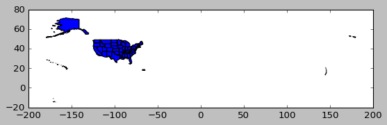

```python
# Plot the geometry
st.plot()
```

Other Census datasets may be available by state or by county within the state. In Python, we use `geopandas` to download and filter county boundaries for the entirety of the United States, or for a specific state like Washington.

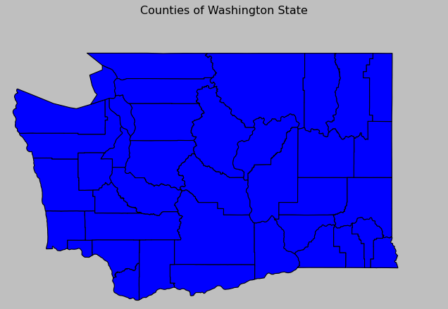

```python
# Download the counties shapefile for the entire US
url = "https://www2.census.gov/geo/tiger/TIGER2021/COUNTY/tl_2021_us_county.zip"
counties = gpd.read_file(url)

# Filter for Washington state counties
wa_counties = counties[counties['STATEFP'] == states.WA.fips]

# Plot Washington counties
fig, ax = plt.subplots(figsize=(10, 10))
wa_counties.plot(ax=ax)
ax.set_title("Counties of Washington State")
plt.axis('off')
plt.show()
```

States and counties are examples of legal entities that can be accessed with `geopandas` in Python, similar to how they are accessed with `tigris` in R. Statistical entities and geographic features are similarly accessed if they exist in the TIGER/Line database. For example, a user might request Census tract boundaries for a given county in Washington using `geopandas` to download and filter the appropriate shapefile.

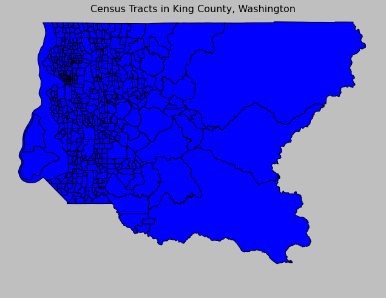

```python
# Download the tracts shapefile for the entire US
url = "https://www2.census.gov/geo/tiger/TIGER2021/TRACT/tl_2021_53_tract.zip"
tracts = gpd.read_file(url)

# Filter for King County tracts
king_county_fips = '033'  # FIPS code for King County
seattle_tracts = tracts[tracts['COUNTYFP'] == king_county_fips]

# Plot King County tracts
fig, ax = plt.subplots(figsize=(10, 10))
seattle_tracts.plot(ax=ax)
ax.set_title("Census Tracts in King County, Washington")
plt.axis('off')
plt.show()
```

## Plotting Geographic Data in Python

Python offers several options for visualizing geographic data that are useful for geospatial analysis. We suggest using `geopandas` with `matplotlib`. Keep in mind that with the `ggplot2` package in R, users will be able to use the `geom_sf()` function to plot spatial data directly.

To plot Census shapes obtained with `geopandas`, we can use the above two libraries with the following code. Note that we first reproject the data to WGS84 (latitude/longitude) to ensure correct plotting, and then adjust the tick labels to show degrees.

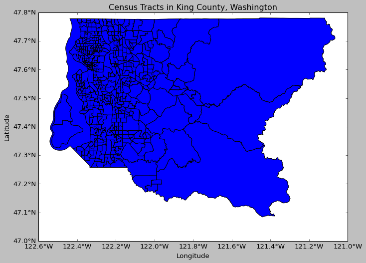

```python
# Reproject to WGS84 (latitude/longitude)
seattle_tracts_geo = seattle_tracts.to_crs(epsg=4326)

fig, ax = plt.subplots(figsize=(10, 10))
seattle_tracts_geo.plot(ax=ax)
plt.title("Census Tracts in King County, Washington")

# Add latitude and longitude to axes
ax.set_xlabel('Longitude')
ax.set_ylabel('Latitude')

# Adjust tick labels to show degrees
def format_coord(x, y):
    return f'{x:.2f}°W, {y:.2f}°N'

ax.format_coord = format_coord

# Set custom tick locations and labels
xticks = ax.get_xticks()
yticks = ax.get_yticks()
ax.set_xticklabels([f'{abs(x):.1f}°W' for x in xticks])
ax.set_yticklabels([f'{y:.1f}°N' for y in yticks])

plt.show()
```

In addition to the traditional TIGER/Line shapefiles, the Census Bureau also makes available cartographic boundary shapefiles. These files are derived from the TIGER/Line shapefiles but are generalized in the interior and clipped to the shoreline of the United States, making them a better choice in many cases than the TIGER/Line shapefiles for thematic mapping. This is especially important when dealing with states that have some connection to water/international boundaries.

For Washington counties data set, we can download both the 2022 TIGER/Line and Cartographic Boundary shapefiles and compare them:

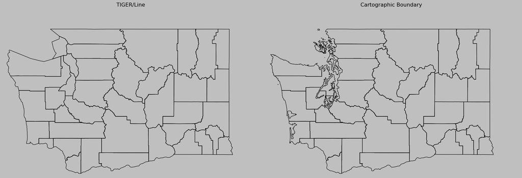

```python
# Download TIGER/Line shapefile for all US counties
url_tiger = "https://www2.census.gov/geo/tiger/TIGER2022/COUNTY/tl_2022_us_county.zip"
us_counties = gpd.read_file(url_tiger)

# Filter for Washington state counties
wa_counties = us_counties[us_counties['STATEFP'] == states.WA.fips]

# Download Cartographic Boundary shapefile for all US counties
url_cb = "https://www2.census.gov/geo/tiger/GENZ2022/shp/cb_2022_us_county_500k.zip"
us_counties_cb = gpd.read_file(url_cb)

# Filter for Washington state counties
wa_counties_cb = us_counties_cb[us_counties_cb['STATEFP'] == states.WA.fips]

# Create two subplots
fig, (ax1, ax2) = plt.subplots(1, 2, figsize=(20, 10))

# Plot TIGER/Line
wa_counties.plot(ax=ax1, edgecolor='black', facecolor='none')
ax1.set_title("TIGER/Line")
ax1.axis('off')

# Plot Cartographic Boundary
wa_counties_cb.plot(ax=ax2, edgecolor='black', facecolor='none')
ax2.set_title("Cartographic Boundary")
ax2.axis('off')

plt.tight_layout()
plt.show()
```

By default, the plots do not display latitude and longitude on the axes. If you want to add latitude and longitude labels to the axes, please refer to the previous step where we manually added these labels using custom formatting.

For geographic data to appropriately represent locations in mapping and geospatial analysis, they must be referenced to some model of the Earth’s surface correctly. We define this representative model of Earth with a *coordinate reference system* (CRS), which specifies not only how data coordinates should be mapped to a model of the Earth’s surface but also how measurements should be computed using a given data set.

To access information about the Coordinate Reference System (CRS) in Python, we can use the `pyproj` library along with `geopandas`. The `pyproj` library allows us to access detailed CRS information, including the Well-Known Text (WKT) representation.

For example, let's take another look at our Washington state data:

```python
# Get the CRS of the data
crs = wa_counties.crs

# Print detailed CRS information
from pyproj import CRS
crs_info = CRS(crs)
print(f"## Coordinate Reference System:\n##   User input: {crs_info.name} \n##   wkt:\n{crs_info.to_wkt()}")
```

```
## Coordinate Reference System:
##   User input: NAD83
##   wkt:
GEOGCRS["NAD83",DATUM["North American Datum 1983",ELLIPSOID["GRS 1980",6378137,298.257222101,LENGTHUNIT["metre",1]]],PRIMEM["Greenwich",0,ANGLEUNIT["degree",0.0174532925199433]],CS[ellipsoidal,2],AXIS["geodetic latitude (Lat)",north,ORDER[1],ANGLEUNIT["degree",0.0174532925199433]],AXIS["geodetic lon…
```

All Census Bureau data sets are stored in the “NAD83” geographic coordinate system, which refers to the North American Datum of 1983. Other relevant information includes the ellipsoid used (GRS 1980, which is a generalized three-dimensional model of the Earth’s shape), the prime meridian of the CRS (Greenwich is used here), and the EPSG (European Petroleum Survey Group) ID of 4269, which is a special code that can be used to represent the CRS in more concise terms.

Thousands of projected CRSs exist in the world. While it can be a challenge to decide on the right projected CRS for your data, the `crsuggest` library in R can help narrow down the choices.

For example, for the mapping of our Washington counties data, the "best choice” is the CRS “NAD83(2011) / Washington North” coordinate reference system, which is available with two different variations on the NAD1983 datum. Let’s choose the second entry, “NAD83(2011) / Washington North”, which is given in meters rather than U.S. feet. Coordinate reference system transformations in `geopandas` are done using the `to_crs()` function.

```python
# Define the target CRS (NAD83(2011) / Washington North, EPSG: 6596)
target_crs = CRS.from_epsg(6596)

   # Transform the CRS
wa_projected = wa_counties_cb.to_crs(target_crs)

# Get the CRS of the transformed data
crs_info = CRS(wa_projected.crs)

# Print detailed CRS information
print(f"## Coordinate Reference System:\n##   User input: {crs_info.to_authority()} \n##   wkt:\n{crs_info.to_wkt()}")
```

```
## Coordinate Reference System:
##   User input: ('EPSG', '6596')
##   wkt:
PROJCRS["NAD83(2011) / Washington North",BASEGEOGCRS["NAD83(2011)",DATUM["NAD83 (National Spatial Reference System 2011)",ELLIPSOID["GRS 1980",6378137,298.257222101,LENGTHUNIT["metre",1]]],PRIMEM["Greenwich",0,ANGLEUNIT["degree",0.0174532925199433]],ID["EPSG",6318]],CONVERSION["SPCS83 Washington Nor…
```

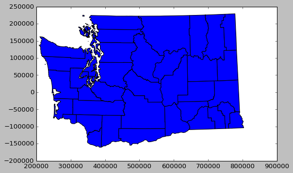

```python
# Plot the transformed geometry, distance in meters
wa_projected.plot()
```

With a properly projected spatial data set, now we can apply any of the geospatial analyst functions (i.e., spatial overlays, intersections, buffers, etc.) without fear of distortion. From a pure mapping perspective, geographic coordinate systems—in latitude and longitude—can work, but we suggest to almost always use a properly projected coordinate reference system.

## Working with Census Geometries

While understanding coordinate reference system transformations is important for spatial data management and geographic visualization, other types of geometric manipulations may be required by the spatial analyst.

A common problem for a national display of the United States is the fragmented nature of US states and territories geographically. The continental United States can be displayed on a map in a relatively straightforward way, and there are a number of projected coordinate reference systems designed for correct display of the continental US. Often, analysts and cartographers then have to make decisions about how to handle Alaska, Hawaii, and Puerto Rico, which cannot be reasonably plotted using default US projections.

For example, let’s take a U.S. state-level shapefile obtained with `geopandas` at low resolution and use `matplotlib` to visualize it in the default geographic CRS, NAD 1983:

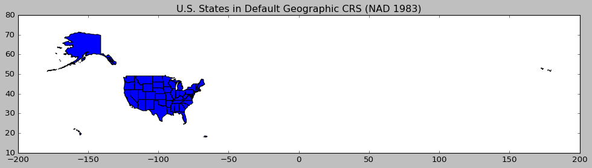

```python
# Load the U.S. state-level shapefile
url_states = "https://www2.census.gov/geo/tiger/GENZ2022/shp/cb_2022_us_state_20m.zip"
us_states = gpd.read_file(url_states)

# Plot the states in the default geographic CRS (NAD 1983)
fig, ax = plt.subplots(figsize=(15, 10))
us_states.plot(ax=ax)
ax.set_title("U.S. States in Default Geographic CRS (NAD 1983)")
plt.show()
```

The plot does not work well, in part because the Aleutian Islands in far west Alaska cross the 180° of longitude and are plotted on the opposite side of the map.

In response, a projected coordinate reference system appropriate for the United States could be used, such as the continental US Albers Equal Area projection:

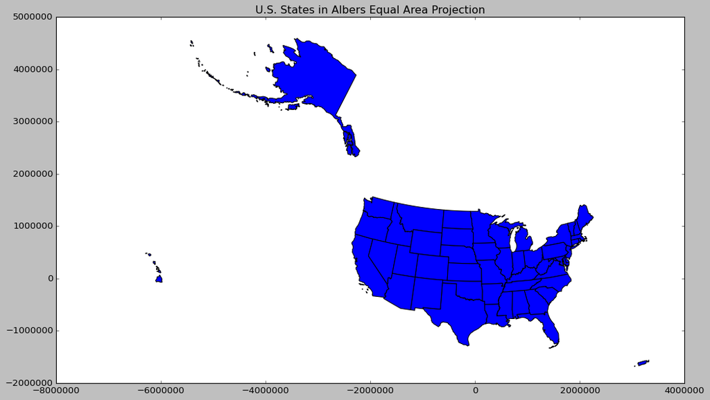

```python
# Define the Albers Equal Area projection for the continental US
albers_equal_area = CRS.from_string("ESRI:102003")

# Transform the CRS
us_states_albers = us_states.to_crs(albers_equal_area)

# Plot the states in the Albers Equal Area projection
fig, ax = plt.subplots(figsize=(15, 10))
us_states_albers.plot(ax=ax)
ax.set_title("U.S. States in Albers Equal Area Projection")
plt.show()
```

While this representation puts all territories in their appropriate locations, it is clearly not appropriate for Alaska, Hawaii, and Puerto Rico which appear distorted.

The `tigris` package in R offers a solution to this problem with the `shift_geometry()` function. This function takes an opinionated approach to the shifting and rescaling of Alaska, Hawaii, and Puerto Rico geometries to offer four options for an alternative view of the US. The function works by projecting geometries in Alaska, Hawaii, and Puerto Rico to appropriate coordinate reference systems for those areas, then re-sizing the geometries (if requested) and moving them to an alternative layout in relationship to the rest of the US using the Albers Equal Area CRS.

In Python, we can achieve a similar result using custom transformations and adjustments. Here is an example of how you might do this:

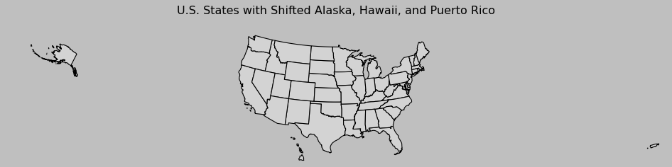

```python
from shapely.affinity import translate, scale
# Function to shift and scale geometries
def shift_and_scale_geometries(gdf, state_fips, xoff, yoff, scale_factor=1.0):
    state_gdf = gdf[gdf['STATEFP'] == state_fips]
    state_gdf = state_gdf.copy()
    state_gdf['geometry'] = state_gdf['geometry'].apply(lambda geom: translate(scale(geom, xfact=scale_factor, yfact=scale_factor, origin='center'), xoff=xoff, yoff=yoff))
    return state_gdf
# Shift and scale Alaska, Hawaii, and Puerto Rico
alaska = shift_and_scale_geometries(us_states_albers, '02', xoff=-3000000, yoff=-2500000, scale_factor=0.35)
hawaii = shift_and_scale_geometries(us_states_albers, '15', xoff=5200000, yoff=-1400000, scale_factor=1.0)
puerto_rico = shift_and_scale_geometries(us_states_albers, '72', xoff=4500000, yoff=500000, scale_factor=1.0)

# Combine the shifted geometries with the rest of the states
contiguous_us = us_states_albers[~us_states_albers['STATEFP'].isin(['02', '15', '72'])]
us_states_shifted = pd.concat([contiguous_us, alaska, hawaii, puerto_rico])

# Plot the shifted geometries
fig, ax = plt.subplots(figsize=(15, 10))
us_states_shifted.plot(ax=ax, color='lightgrey', edgecolor='black')

# Set minimal theme
ax.set_title("U.S. States with Shifted Alaska, Hawaii, and Puerto Rico")
ax.set_axis_off()
plt.show()
```

## Mapping Census and ACS Estimates in Python

Data from the United States Census Bureau are commonly visualized using maps, as both Census and ACS data are aggregated to enumeration units. Here, we will introduce the combined use of `census` and `geopandas` to investigate the spatial dimensions of Census and ACS data.

Consider 2022 ACS median household income at the Census tract level in the District of Columbia:

```python
# load libraries and get your API key first

# Fetch ACS data for median household income at the Census tract level in DC
dc_income_data = c.acs5.state_county_tract(
    fields=["B19013_001E"],
    state_fips=states.DC.fips,
    county_fips="*",
    tract="*",
    year=2022
)

# Convert to DataFrame
dc_income_df = pd.DataFrame(dc_income_data)

# Display the first few rows
print(dc_income_df.head())
```

```
   B19013_001E state county   tract
0     168705.0    11    001  000101
1     178790.0    11    001  000102
2 -666666666.0    11    001  000201
3     170500.0    11    001  000202
4     176181.0    11    001  000300
```

Median household income data are found in the variable column (`B19013_001E`), along with state, county and Tract codes. We now merge the ACS data with the Census tract geometry data using the Tract code.

```python
# For DC tracts specifically
url_dc_tracts = "https://www2.census.gov/geo/tiger/TIGER2022/TRACT/tl_2022_11_tract.zip"
dc_tracts = gpd.read_file(url_dc_tracts)
# Merge the ACS data with the geometry
dc_income = dc_tracts.merge(dc_income_df, left_on="TRACTCE", right_on="tract")

# Display the column names
print(dc_income.columns)
```

```
Index(['STATEFP', 'COUNTYFP', 'TRACTCE', 'GEOID', 'NAME', 'NAMELSAD', 'MTFCC',
       'FUNCSTAT', 'ALAND', 'AWATER', 'INTPTLAT', 'INTPTLON', 'geometry',
       'B19013_001E', 'state', 'county', 'tract'],
      dtype='object')
```

Both geometry and attributes can be visualized using `matplotlib`. The code below returns a simple map showing income variation in Washington, DC. Wealthier areas, as represented with warmer colors, tend to be located in the northwestern part of the District. NA values are represented on the map in white.

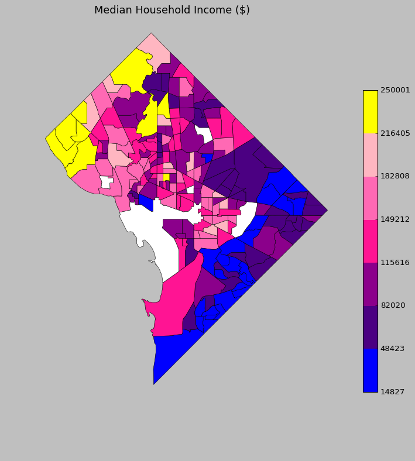

```python
import matplotlib.colors as colors

# Ensure 'estimate' is numeric and replace -666666666.0 with NaN
dc_income['estimate'] = pd.to_numeric(dc_income['B19013_001E'], errors='coerce')
dc_income['estimate'] = dc_income['estimate'].replace(-666666666.0, np.nan)

# Create a custom colormap
colors_list = ['#0000FF', '#4B0082', '#8B008B', '#FF1493', '#FF69B4', '#FFB6C1', '#FFFF00']
n_bins = len(colors_list)
cmap = colors.ListedColormap(colors_list)
bounds = np.linspace(dc_income['estimate'].min(), dc_income['estimate'].max(), n_bins + 1)
norm = colors.BoundaryNorm(bounds, cmap.N)

# Create the plot
fig, ax = plt.subplots(figsize=(10, 10))

# Plot the data
dc_income.plot(column='estimate', ax=ax, cmap=cmap, norm=norm,
               edgecolor='black', linewidth=0.5,
               missing_kwds={'color': 'white', 'edgecolor': 'black'},
               legend_kwds={'label': 'Median Household Income ($)',
                            'orientation': 'horizontal'})
# Remove axes
ax.axis('off')

# Add a title
ax.set_title('Median Household Income ($)', fontsize=16, loc='center', pad=20)

# Add colorbar
sm = plt.cm.ScalarMappable(cmap=cmap, norm=norm)
sm.set_array([])
cbar = fig.colorbar(sm, ax=ax, orientation='vertical', shrink=0.7, aspect=20)
cbar.set_ticks(bounds)
cbar.set_ticklabels([f'{b:.0f}' for b in bounds])

# Adjust layout
plt.tight_layout()

# Show the plot
plt.show()
```

### Map-Making with `matplotlib` and `geopandas`

`matplotlib`and `geopandas` can be used for plotting of GeoDataFrames in Python.

Let's consider the 2019 ACS 1-year estimates for median age by state:

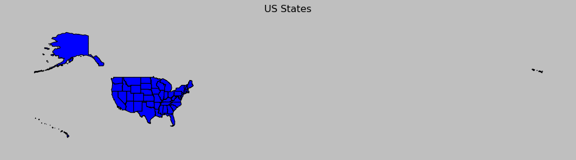

```python
# Fetch ACS data for median age by state for all states
us_median_age_data = []
for state in states.STATES:
    data = c.acs1.state(
        fields=["B01002_001E"],
        state_fips=state.fips,
        year=2019
    )
    us_median_age_data.extend(data)

# Convert to DataFrame
us_median_age_df = pd.DataFrame(us_median_age_data)

# Load US states shapefile
url_states = "https://www2.census.gov/geo/tiger/TIGER2019/STATE/tl_2019_us_state.zip"
us_states = gpd.read_file(url_states)

# Merge ACS data with geometry
us_median_age = us_states.merge(us_median_age_df, left_on="STATEFP", right_on="state")

# Plot the geometry
fig, ax = plt.subplots(figsize=(15, 10))
us_median_age.plot(ax=ax)
plt.title("US States")
plt.axis('off')
plt.show()
```

We then style the state polygons `matplotlib`, producing a colored map of median age by state using CRS.

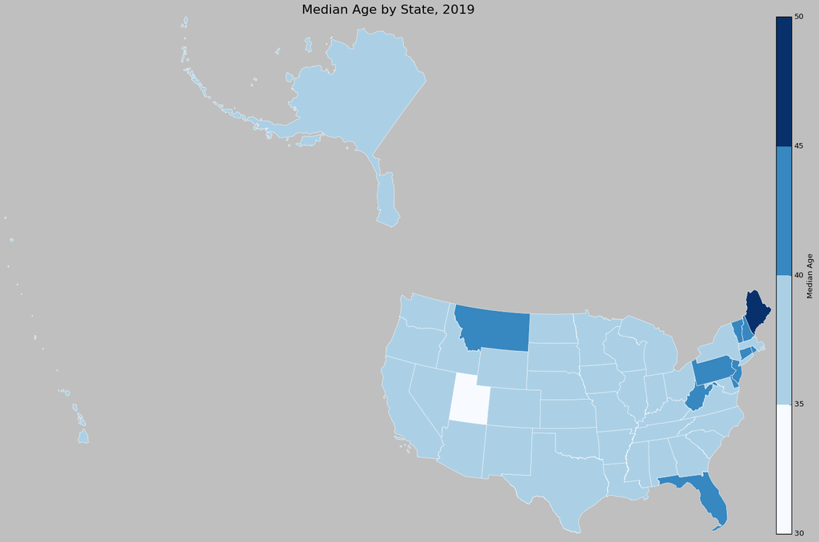

```python
from mpl_toolkits.axes_grid1 import make_axes_locatable

# Set the projection (use a US-specific projection)
us_median_age = us_median_age.to_crs(epsg=2163)

# Create the plot
fig, ax = plt.subplots(figsize=(20, 12))

# Create a custom colormap with simplified scale
cmap = plt.get_cmap('Blues')
bounds = [30, 35, 40, 45, 50]
norm = colors.BoundaryNorm(bounds, cmap.N)

# Plot the map
us_median_age.plot(column='B01002_001E', ax=ax, cmap=cmap, norm=norm,
                   edgecolor='white', linewidth=0.5)

# Add colorbar
divider = make_axes_locatable(ax)
cax = divider.append_axes("right", size="2%", pad=0.1)
sm = plt.cm.ScalarMappable(cmap=cmap, norm=norm)
sm.set_array([])
cbar = fig.colorbar(sm, cax=cax, ticks=bounds)
cbar.set_label('Median Age', fontsize=12)

# Customize the plot
ax.set_title('Median Age by State, 2019', fontsize=20)

# Remove axis labels and ticks
ax.set_axis_off()

# Set aspect to equal for true shape
ax.set_aspect('equal')

# Adjust the plot extent to focus on the main part of the US
ax.set_xlim(us_median_age.total_bounds[0], us_median_age.total_bounds[2])
ax.set_ylim(us_median_age.total_bounds[1], us_median_age.total_bounds[3])

# Adjust layout to make map larger
plt.tight_layout()
plt.subplots_adjust(right=0.9)

plt.show()
```

`geopandas` and `matplotlib` also offer a wide range of functionality for custom cartography.

Let's consider total population by Census tract in King County, Washington.

```python
# Fetch decennial Census data for King County, WA
king_pop_data = c.pl.state_county_tract(
    fields=["P1_001N"],
    state_fips=states.WA.fips,
    county_fips="033",  # King County FIPS
    tract="*",
    year=2020
)

# Convert to DataFrame
king_pop_df = pd.DataFrame(king_pop_data)

# Load WA state tracts shapefile
url_WA_tracts = "https://www2.census.gov/geo/tiger/TIGER2020/TRACT/tl_2020_53_tract.zip"
wa_tracts = gpd.read_file(url_WA_tracts)

# Filter for King County tracts
king_tracts = wa_tracts[wa_tracts['COUNTYFP'] == '033']

# Merge Census data with geometry
king_pop = king_tracts.merge(king_pop_df, left_on="TRACTCE", right_on="tract")

print(king_pop.columns)
```

```
Index(['STATEFP', 'COUNTYFP', 'TRACTCE', 'GEOID', 'NAME', 'NAMELSAD', 'MTFCC',
       'FUNCSTAT', 'ALAND', 'AWATER', 'INTPTLAT', 'INTPTLON', 'geometry',
       'P1_001N', 'state', 'county', 'tract'],
      dtype='object')
```

King County, Washington is an example of a complex Census tract geometry, given that one tract has no population (waterways surrounding Seattle). We should remove this tract before proceeding with any mapping. To do this, we'll use pandas filtering.

```python
# Remove tract with no population (if any)
missing_pop = "53033990100"
king_pop = king_pop[king_pop['GEOID'] != missing_pop]
```

`geopanda`'s map-making syntax integrates well with `matplotlib`, allowing us to create layers and customize the map. We initialize the map with `plt.subplots()`, then use the `plot()` method of the GeoDataFrame to add the Census tracts.

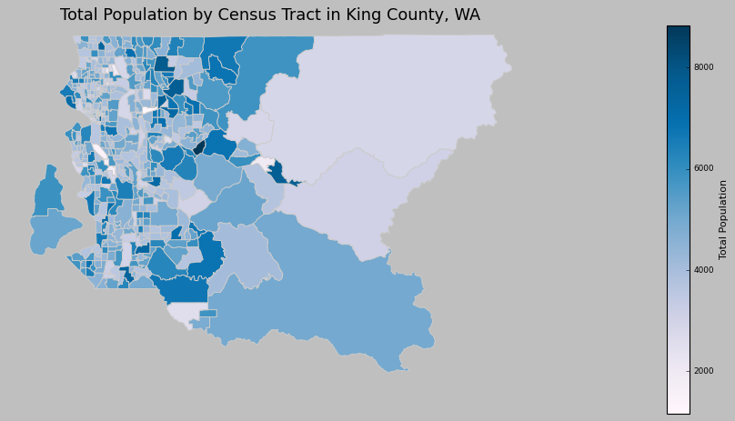

```python
# Create a map
fig, ax = plt.subplots(figsize=(12, 8))

# Plot the map
im = king_pop.plot(column='P1_001N', ax=ax, cmap='PuBu',
                   edgecolor='0.8', linewidth=0.8, legend=False)

# Customize the plot
ax.set_title('Total Population by Census Tract in King County, WA', fontsize=16)
ax.axis('off')

# Add a smaller colorbar
divider = make_axes_locatable(ax)
cax = divider.append_axes("right", size="3%", pad=0.1)  # Reduced size from 5% to 3%

# Create colorbar with fewer ticks
sm = plt.cm.ScalarMappable(cmap='PuBu', norm=plt.Normalize(vmin=king_pop['P1_001N'].min(), vmax=king_pop['P1_001N'].max()))
sm.set_array([])
cbar = fig.colorbar(sm, cax=cax)
cbar.set_label('Total Population', fontsize=10)

# Set fewer ticks on the colorbar
cbar.locator = plt.MaxNLocator(nbins=5)
cbar.update_ticks()

# Adjust tick label size
cbar.ax.tick_params(labelsize=8)

plt.tight_layout()
plt.show()
```

The Census API offers all available Census and ACS variables. This makes other map types (e.g., dot-density maps) easier to create. Let's try to create a dot-density map of race in King County, Washington by preparing the data first.

```python
# Fetch race data
race_variables = {
    'Hispanic': 'P2_002N',
    'White': 'P2_005N',
    'Black': 'P2_006N',
    'Native': 'P2_007N',
    'Asian': 'P2_008N'
}

king_race_data = c.pl.state_county_tract(
    fields=list(race_variables.values()) + ['P2_001N'],
    state_fips=states.WA.fips,
    county_fips="033",
    tract="*",
    year=2020
)

# Convert to DataFrame and merge with geometry
king_race_df = pd.DataFrame(king_race_data)
king_race = king_tracts.merge(king_race_df, left_on="TRACTCE", right_on="tract")

# Melt the DataFrame to create a long format
king_race_long = pd.melt(king_race, id_vars=['geometry', 'GEOID', 'P2_001N'],
                         value_vars=list(race_variables.values()),
                         var_name='variable', value_name='value')

# Calculate percentages
king_race_long['percent'] = 100 * king_race_long['value'] / king_race_long['P2_001N']

# Remove zero populations/percentages
king_race_long = king_race_long[king_race_long['value'] > 0]
```

Now let's create the dot-density map of race in King County, Washington. In Python, we'll need to manually create the dots for each race category. Note that in R, you can use the `tmap` package, which has built-in functions for creating dot-density maps.

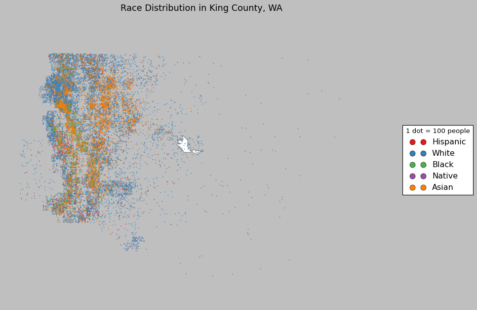

```python
fig, ax = plt.subplots(figsize=(12, 8))

# Plot background
background_tracts = king_race[king_race['P2_005N'] == king_race['P2_005N'].max()]
background_tracts.plot(ax=ax, color='white', edgecolor='grey')

# Plot dots
for race, color in zip(race_variables.keys(), plt.cm.Set1.colors):
    race_data = king_race_long[king_race_long['variable'] == race_variables[race]]
    for _, row in race_data.iterrows():
        n_dots = int(row['value'] / 100)  # 1 dot = 100 people
        x = np.random.uniform(row['geometry'].bounds[0], row['geometry'].bounds[2], n_dots)
        y = np.random.uniform(row['geometry'].bounds[1], row['geometry'].bounds[3], n_dots)
        ax.scatter(x, y, color=color, s=1, alpha=0.5)

ax.set_title('Race Distribution in King County, WA', fontsize=16)
ax.axis('off')

# Add legend
from matplotlib.lines import Line2D
legend_elements = [Line2D([0], [0], marker='o', color='w', label=race,
                          markerfacecolor=color, markersize=10)
                   for race, color in zip(race_variables.keys(), plt.cm.Set1.colors)]
ax.legend(handles=legend_elements, title='1 dot = 100 people', loc='center left', bbox_to_anchor=(1, 0.5))

plt.tight_layout()
plt.show()
```

This Python code creates a dot-density map showing the relative racial and ethnic heterogeneity of Census tracts in King County. Each dot represents 100 people, and the colors correspond to different racial/ethnic categories.

# Areal interpolation

Areal interpolation is the process of estimating values from a source set of polygons to an overlapping but non-congruent set of target polygons. This technique is helpful when a project requires spatial analysis at a scale not included in the Census enumerations.

In Python, we can perform areal interpolation using libraries such as `matplotlib` and `tobler`.

Let's consider a problem where HOLC Neighborhood designations are used to express socioeconomic and demographic data.

First, we'll read in the HOLC spatial data and plot it according to neighborhood designation. Shreveport, Louisiana HOLC designations are found [here](https://dsl.richmond.edu/panorama/redlining/data).

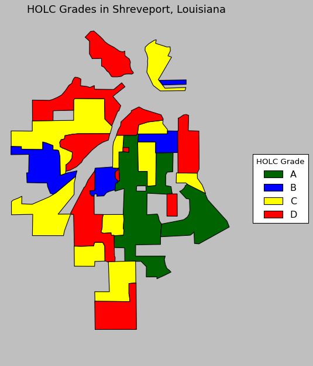

```python
from matplotlib.colors import ListedColormap
from matplotlib.patches import Patch

# Read the HOLC spatial data
ShreveportHOLC = gpd.read_file("Data/Shreveport.json")

# Remove industrial and commercial grades
ShreveportHOLC = ShreveportHOLC[ShreveportHOLC['grade'] != "NA"]

# Define color palette
pal = ["darkgreen", "blue", "yellow", "red"]
cmap = ListedColormap(pal)

# Create a mapping of grades to numeric values
grade_map = {'A': 0, 'B': 1, 'C': 2, 'D': 3}
ShreveportHOLC['grade_num'] = ShreveportHOLC['grade'].map(grade_map)

# Create the plot
fig, ax = plt.subplots(figsize=(12, 8))

# Plot the HOLC data
ShreveportHOLC.plot(column='grade_num', ax=ax, cmap=cmap, legend=False)

# Customize the plot
ax.set_title('HOLC Grades in Shreveport, Louisiana', fontsize=16)
ax.axis('off')

# Create legend manually
legend_elements = [Patch(facecolor=color, edgecolor='black', label=grade)
                   for grade, color in zip(['A', 'B', 'C', 'D'], pal)]

ax.legend(handles=legend_elements, title='HOLC Grade',
          loc='center left', bbox_to_anchor=(1, 0.5))

plt.tight_layout()
plt.show()
```

```python
# Function to fetch data for a single county
def get_county_data(state_fips, county_fips):
    return c.pl.state_county_tract(
        fields=["P1_001N"],
        state_fips=state_fips,
        county_fips=county_fips,
        tract="*",
        year=2020
    )

# Fetch Census data for Shreveport (Caddo and Bossier counties)
caddo_data = get_county_data(states.LA.fips, "017")
bossier_data = get_county_data(states.LA.fips, "015")

# Combine the data
shreveport_pop_data = caddo_data + bossier_data

# Convert to DataFrame
shreveport_pop_df = pd.DataFrame(shreveport_pop_data)

# Rename the population column
shreveport_pop_df = shreveport_pop_df.rename(columns={"P1_001N": "Total_Pop"})

# Load tract geometries
url_la_tracts = "https://www2.census.gov/geo/tiger/TIGER2020/TRACT/tl_2020_22_tract.zip"
la_tracts = gpd.read_file(url_la_tracts)

# Merge Census data with geometry
shreveport_pop = la_tracts.merge(shreveport_pop_df, left_on="TRACTCE", right_on="tract")

# Filter for only Caddo and Bossier counties
shreveport_pop = shreveport_pop[shreveport_pop['COUNTYFP'].isin(['017', '015'])]

# Convert Total_Pop to numeric
shreveport_pop['Total_Pop'] = pd.to_numeric(shreveport_pop['Total_Pop'])
```

```
(-94.10000000000001, -93.30000000000001, 32.0, 33.2)
```

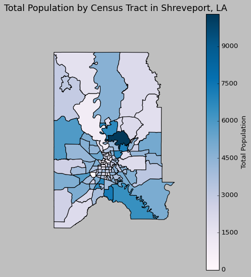

```python
# Create the plot
fig, ax = plt.subplots(figsize=(12, 8))

# Calculate quantile breaks manually
quantiles = shreveport_pop['Total_Pop'].quantile([0.2, 0.4, 0.6, 0.8])

# Plot the data
shreveport_pop.plot(column='Total_Pop', ax=ax,
                    cmap='PuBu',
                    legend=True,
                    legend_kwds={'label': 'Total Population'},
                    # scheme='UserDefined',
                    classification_kwds={'bins': quantiles})

# Customize the plot
ax.set_title('Total Population by Census Tract in Shreveport, LA', fontsize=16)
ax.axis('off')
```

To calculate the total population within HOLC neighborhood grades, we need to perform areal interpolation, adjusting the Census tract data to match the spatial dimensions of the HOLC neighborhoods.

We start by adding an "ID" column to both spatial datasets, which is necessary for the `area_interpolate()` function to work correctly. It's also crucial to ensure that the Coordinate Reference System (CRS) for each spatial dataset is projected in the same reference system. We accomplish this using the `to_crs()` method in geopandas.

We use the `tobler`library, specifically the `area_interpolate()` function, which is analogous to the `aw_interpolate()` function in R's `areal` package. This function performs area-weighted interpolation, estimating population values for the HOLC neighborhoods based on the overlapping Census tracts.

The process involves the following steps:

1. Adding unique ID columns to both the HOLC and Census tract datasets.
2. Transforming both datasets to the same CRS (EPSG:5070 in this case).
3. Performing the areal interpolation using `area_interpolate()`.
4. Rounding the interpolated population values to whole numbers.

This approach allows us to estimate the population within each HOLC neighborhood grade, providing a way to analyze demographic patterns in relation to historical redlining practices.

```python
from tobler.area_weighted import area_interpolate

# Add ID columns
ShreveportHOLC['ID'] = range(1, len(ShreveportHOLC) + 1)
shreveport_pop['ID2'] = range(1, len(shreveport_pop) + 1)

# Ensure CRS is the same for both datasets
ShreveportHOLC = ShreveportHOLC.to_crs(epsg=4326).to_crs(epsg=5070)
shreveport_pop = shreveport_pop.to_crs(epsg=5070)

# Perform areal interpolation
interpolated_output = area_interpolate(
    source_df=shreveport_pop,
    target_df=ShreveportHOLC,
    extensive_variables=['Total_Pop'],
    intensive_variables=None,
    allocate_total=True
)
# Round the interpolated values
interpolated_output['Total_Pop'] = np.round(interpolated_output['Total_Pop']).astype(int)

# Print column names
print("Available columns:", interpolated_output.columns)

# Select columns to display
display_columns = ['Total_Pop']
if 'ID' in interpolated_output.columns:
    display_columns.insert(0, 'ID')
if 'grade' in interpolated_output.columns:
    display_columns.insert(1, 'grade')

# Print the first few rows of the result
print(interpolated_output[display_columns].head())
```

```
Available columns: Index(['Total_Pop', 'geometry'], dtype='object')
   Total_Pop
0      14963
1       6751
2       4763
3        553
4       1618
```

Now we have a total population count for each HOLC neighborhood designation (26 polygons).

We can then map total population by neighborhood individually:

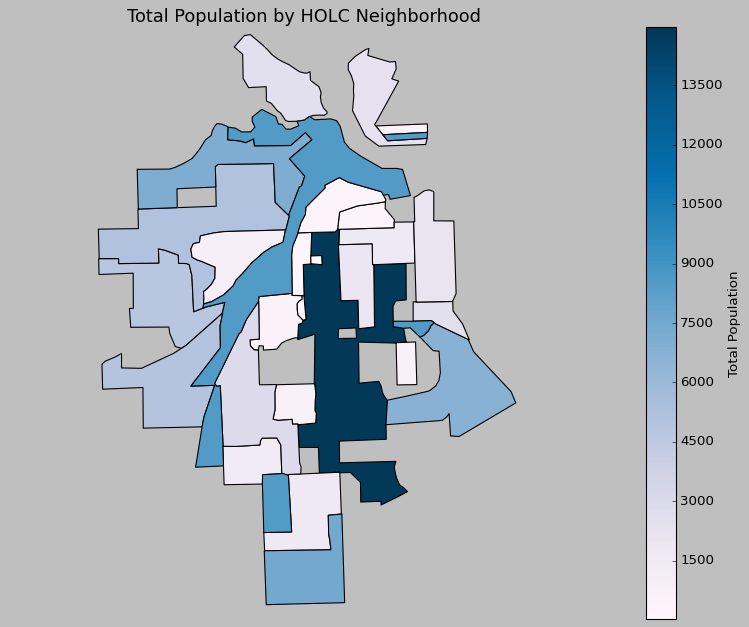

```python
# Create the plot
fig, ax = plt.subplots(figsize=(12, 8))

# Calculate quantile breaks manually
quantiles = interpolated_output['Total_Pop'].quantile([0.2, 0.4, 0.6, 0.8])

# Plot the data
interpolated_output.plot(column='Total_Pop', ax=ax,
                         cmap='PuBu',
                         legend=True,
                         legend_kwds={'label': 'Total Population'},
                         # scheme='UserDefined',
                         classification_kwds={'bins': quantiles})

# Customize the plot
ax.set_title('Total Population by HOLC Neighborhood', fontsize=16)
ax.axis('off')

plt.tight_layout()
plt.show()
```

Or we can map total population by neighborhood grouped:

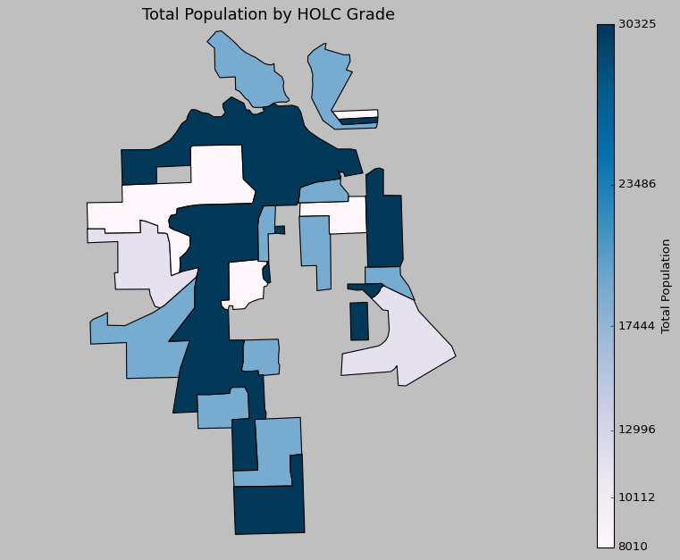

```python
# Merge the ID and grade information from ShreveportHOLC
interpolated_output = interpolated_output.merge(ShreveportHOLC[['ID', 'grade']], left_index=True, right_on='ID')# Group by grade and sum the population

# Group by grade and sum the population
interpolated_output_grouped = interpolated_output.dissolve(by='grade', aggfunc='sum')

# Create the plot
import matplotlib.pyplot as plt

fig, ax = plt.subplots(figsize=(12, 8))

# Calculate quantile breaks manually
quantiles = interpolated_output_grouped['Total_Pop'].quantile([0, 0.2, 0.4, 0.6, 0.8, 1])

# Create a color map
cmap = plt.get_cmap('PuBu')
norm = plt.Normalize(vmin=quantiles.min(), vmax=quantiles.max())

# Plot the data
interpolated_output_grouped.plot(column='Total_Pop', ax=ax,
                                 cmap=cmap,
                                 norm=norm,
                                 legend=False)

# Create colorbar
sm = plt.cm.ScalarMappable(cmap=cmap, norm=norm)
sm.set_array([])
cbar = fig.colorbar(sm, ax=ax, orientation='vertical', aspect=30, pad=0.08)
cbar.set_label('Total Population', fontsize=12)

# Adjust colorbar tick labels
cbar.set_ticks(quantiles)
cbar.set_ticklabels([f'{q:.0f}' for q in quantiles])

# Customize the plot
ax.set_title('Total Population by HOLC Grade', fontsize=16)
ax.axis('off')

plt.tight_layout()
plt.show()
```

Plot with the HOLC neighborhood designations side-by-side.

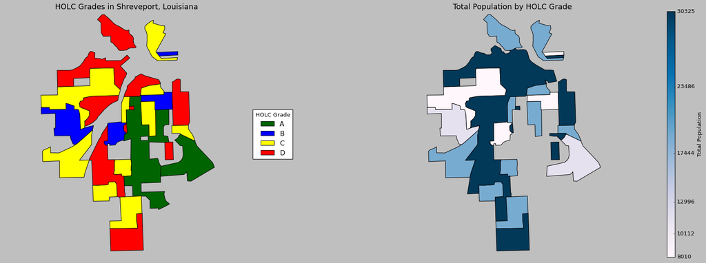

```
grade
A    11514
B     8010
C    18926
D    30325
Name: Total_Pop, dtype: int64
```

```python
from matplotlib.patches import Patch

# Create a figure with two subplots side by side
fig, (ax1, ax2) = plt.subplots(1, 2, figsize=(24, 8))

# Plot 1: HOLC Grades
pal = ["darkgreen", "blue", "yellow", "red"]
cmap_holc = ListedColormap(pal)

# Plot the HOLC data
ShreveportHOLC.plot(column='grade_num', ax=ax1, cmap=cmap_holc, legend=False)

# Customize the first plot
ax1.set_title('HOLC Grades in Shreveport, Louisiana', fontsize=16)
ax1.axis('off')

# Create legend manually for the first plot
legend_elements = [Patch(facecolor=color, edgecolor='black', label=grade)
                   for grade, color in zip(['A', 'B', 'C', 'D'], pal)]

ax1.legend(handles=legend_elements, title='HOLC Grade',
           loc='center left', bbox_to_anchor=(1, 0.5))

# Plot 2: Total Population by HOLC Grade
# Calculate quantile breaks manually
quantiles = interpolated_output_grouped['Total_Pop'].quantile([0, 0.2, 0.4, 0.6, 0.8, 1])

# Create a color map for the second plot
cmap_pop = plt.get_cmap('PuBu')
norm = plt.Normalize(vmin=quantiles.min(), vmax=quantiles.max())

# Plot the data for the second plot
interpolated_output_grouped.plot(column='Total_Pop', ax=ax2,
                                 cmap=cmap_pop,
                                 norm=norm,
                                 legend=False)

# Create colorbar for the second plot
sm = plt.cm.ScalarMappable(cmap=cmap_pop, norm=norm)
sm.set_array([])
cbar = fig.colorbar(sm, ax=ax2, orientation='vertical', aspect=30, pad=0.08)
cbar.set_label('Total Population', fontsize=12)

# Adjust colorbar tick labels
cbar.set_ticks(quantiles)
cbar.set_ticklabels([f'{q:.0f}' for q in quantiles])

# Customize the second plot
ax2.set_title('Total Population by HOLC Grade', fontsize=16)
ax2.axis('off')

# Adjust layout and display
plt.tight_layout()
plt.show()

# Print the total population for each HOLC grade
print(interpolated_output_grouped['Total_Pop'])
```